# 线性代数 R 语言实验教程

从变换思维到几何直觉

Author

线性代数实验课

Published

February 19, 2026

# 引言

本教程通过 R 语言实验，将线性代数中的核心概念——线性变换、特征值、正交投影、二次型、奇异值分解、迹与范数——转化为可运行、可观察、可交互的计算实验。每个实验都配有可视化，帮助你建立**变换思维**和**图形直觉**。

> **使用方法**：用 Quarto 渲染此文档（`quarto render`），或在 RStudio 中逐块运行代码。建议你修改参数、观察变化，形成自己的理解。

# 1 准备工作

```r
# ---- 辅助函数 ----

# 画二维向量（箭头）
draw_vector <- function(v, origin = c(0, 0), col = "blue", lwd = 2, label = NULL) {
  arrows(origin[1], origin[2],
         origin[1] + v[1], origin[2] + v[2],
         col = col, lwd = lwd, length = 0.10)
  if (!is.null(label)) {
    text(origin[1] + v[1] * 1.08,
         origin[2] + v[2] * 1.08,
         label, col = col, cex = 0.85, font = 2)
  }
}

# 向量范数
vnorm <- function(x) sqrt(sum(x^2))

# 单位圆点集
unit_circle <- function(n = 300) {
  theta <- seq(0, 2 * pi, length.out = n)
  rbind(cos(theta), sin(theta))
}

# 网格点集（用于可视化变换）
grid_points <- function(from = -1, to = 1, by = 0.25) {
  s <- seq(from, to, by = by)
  pts <- list()
  # 横线
  for (yi in s) {
    xi <- seq(from, to, length.out = 80)
    pts[[length(pts) + 1]] <- rbind(xi, rep(yi, length(xi)))
  }
  # 竖线
  for (xi in s) {
    yi <- seq(from, to, length.out = 80)
    pts[[length(pts) + 1]] <- rbind(rep(xi, length(yi)), yi)
  }
  pts
}

# 画网格
draw_grid <- function(grid_list, col = "steelblue", lwd = 0.6, ...) {
  for (g in grid_list) {
    lines(g[1, ], g[2, ], col = col, lwd = lwd, ...)
  }
}
```

# 2 第一章：线性变换

## 2.1 实验 1.1 —— 矩阵乘法是列向量的线性组合

矩阵 $A$ 乘以向量 $x$ 的本质是：取 $A$ 的列向量，以 $x$ 的分量为权重进行线性组合。即 $Ax = x_1 a_1 + x_2 a_2 + \cdots + x_n a_n$。

```r
A <- matrix(c(2, 1,
              1, 3), nrow = 2, byrow = TRUE)
x <- c(1.5, 0.8)

a1 <- A[, 1]   # 第一列
a2 <- A[, 2]   # 第二列
b  <- A %*% x  # 矩阵乘法

cat("A 的第1列 a1 =", a1, "\n")
```

```
A 的第1列 a1 = 2 1
```

```r
cat("A 的第2列 a2 =", a2, "\n")
```

```
A 的第2列 a2 = 1 3
```

```r
cat("x =", x, "\n")
```

```
x = 1.5 0.8
```

```r
cat("Ax =", b, "\n")
```

```
Ax = 3.8 3.9
```

```r
cat("x1*a1 + x2*a2 =", x[1] * a1 + x[2] * a2, "\n")
```

```
x1*a1 + x2*a2 = 3.8 3.9
```

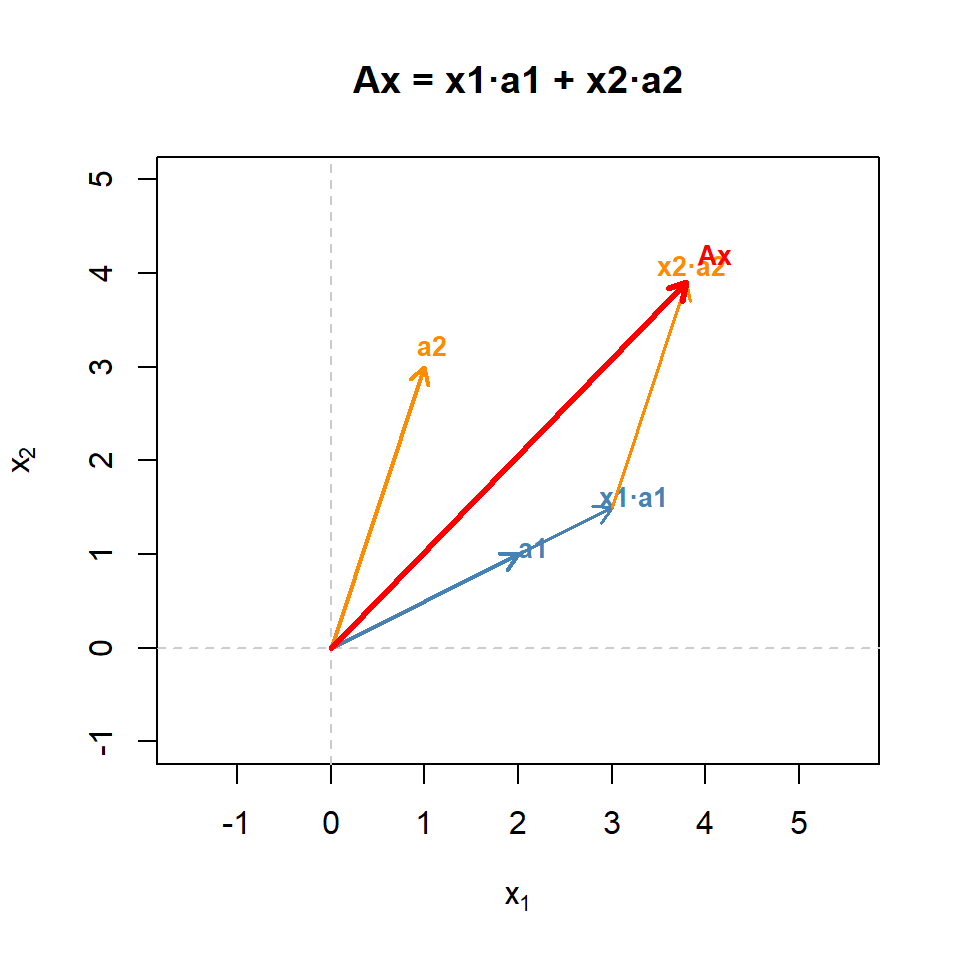

```r
# 可视化
plot(NULL, xlim = c(-1, 5), ylim = c(-1, 5), asp = 1,
     xlab = expression(x[1]), ylab = expression(x[2]),
     main = "Ax = x1·a1 + x2·a2")
abline(h = 0, v = 0, col = "gray80", lty = 2)

draw_vector(a1, col = "steelblue", lwd = 2, label = "a1")
draw_vector(a2, col = "darkorange", lwd = 2, label = "a2")
draw_vector(x[1] * a1, col = "steelblue", lwd = 1.5, label = "x1·a1")
draw_vector(x[2] * a2, origin = x[1] * a1, col = "darkorange", lwd = 1.5, label = "x2·a2")
draw_vector(as.numeric(b), col = "red", lwd = 3, label = "Ax")
```

**观察**：红色向量 $Ax$ 恰好等于蓝色部分 $x_1 a_1$ 与橙色部分 $x_2 a_2$ 的首尾相接。矩阵乘法就是列向量的加权求和。

## 2.2 实验 1.2 —— 可视化二维线性变换

矩阵 $A \in \mathbb{R}^{2 \times 2}$ 定义了平面到平面的线性映射。我们把一组网格线通过 $A$ 变换，观察空间是如何被”揉搓”的。

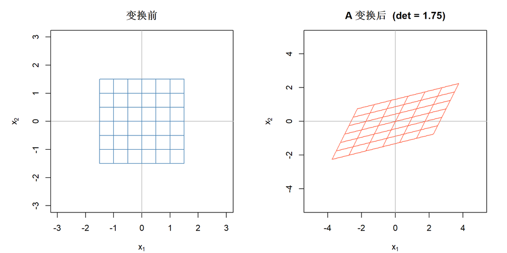

```r
A <- matrix(c(2, 0.5,
              0.5, 1), nrow = 2, byrow = TRUE)

grd <- grid_points(from = -1.5, to = 1.5, by = 0.5)
grd_transformed <- lapply(grd, function(g) A %*% g)

par(mfrow = c(1, 2), pty = "s", mar = c(4, 4, 3, 1))

# 变换前
plot(NULL, xlim = c(-3, 3), ylim = c(-3, 3), asp = 1,
     xlab = expression(x[1]), ylab = expression(x[2]),
     main = "变换前")
abline(h = 0, v = 0, col = "gray70")
draw_grid(grd, col = "steelblue", lwd = 1)

# 变换后
plot(NULL, xlim = c(-5, 5), ylim = c(-5, 5), asp = 1,
     xlab = expression(x[1]), ylab = expression(x[2]),
     main = paste0("A 变换后  (det = ", round(det(A), 2), ")"))
abline(h = 0, v = 0, col = "gray70")
draw_grid(grd_transformed, col = "tomato", lwd = 1)
```

**动手练习**：把 $A$ 改为 `matrix(c(0,-1,1,0), 2, 2)`（旋转90°），或 `matrix(c(1,0,0,-1), 2, 2)`（关于 $x_1$ 轴的反射），观察网格如何变化。

## 2.3 实验 1.3 —— 列空间：$Ax$ 能到达哪里？

对于 $A \in \mathbb{R}^{m \times n}$，所有可能的 $Ax$ 构成了列空间 $\text{Col}(A)$。

```r
# A 是 3x2 矩阵：从 R^2 映射到 R^3
# 列空间是 R^3 中的一个 2 维平面
A <- matrix(c(1, 0, 1,
              0, 1, 1), nrow = 3, ncol = 2)
cat("A =\n"); print(A)
```

```
A =
```

```
     [,1] [,2]
[1,]    1    0
[2,]    0    1
[3,]    1    1
```

```r
cat("A 的秩 =", qr(A)$rank, "\n")
```

```
A 的秩 = 2
```

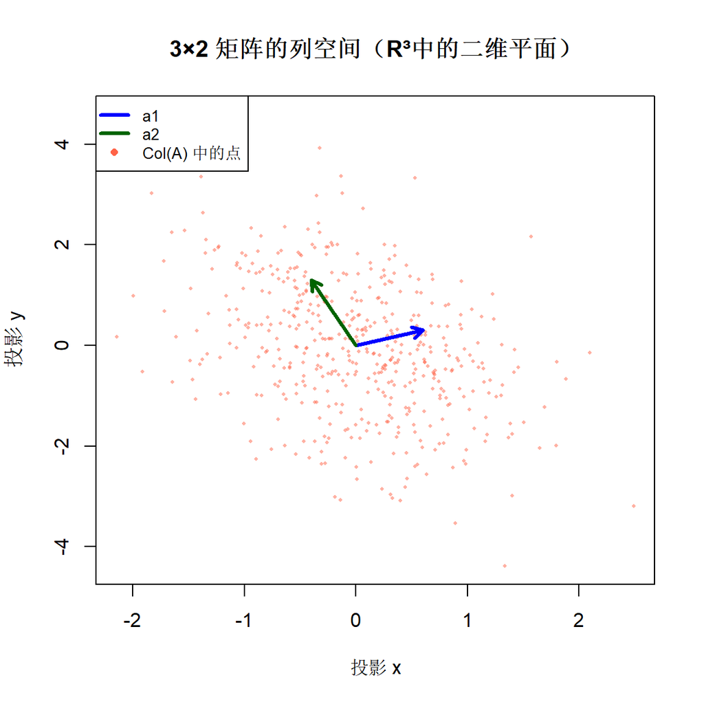

```r
# 随机采样 500 个 x ∈ R^2，计算 Ax
set.seed(42)
X <- matrix(rnorm(2 * 500), nrow = 2)
AX <- A %*% X  # 3 x 500

# 投影到 2D 来可视化 R^3 中的平面
# 使用简单的等轴测投影
proj_x <- AX[1, ] - 0.4 * AX[3, ]
proj_y <- AX[2, ] + 0.3 * AX[3, ]

plot(proj_x, proj_y, pch = 16, cex = 0.4, col = adjustcolor("tomato", 0.5),
     xlab = "投影 x", ylab = "投影 y",
     main = "3×2 矩阵的列空间（R³中的二维平面）")
# 画列向量
a1 <- A[, 1]; a2 <- A[, 2]
arrows(0, 0, a1[1] - 0.4*a1[3], a1[2] + 0.3*a1[3],
       col = "blue", lwd = 3, length = 0.1)
arrows(0, 0, a2[1] - 0.4*a2[3], a2[2] + 0.3*a2[3],
       col = "darkgreen", lwd = 3, length = 0.1)
legend("topleft", c("a1", "a2", "Col(A) 中的点"),
       col = c("blue", "darkgreen", "tomato"), lwd = c(3, 3, NA),
       pch = c(NA, NA, 16), cex = 0.8)
```

**观察**：所有 $Ax$ 都落在由 $a_1$ 和 $a_2$ 张成的二维平面上。$x$ 在 $\mathbb{R}^2$ 中取遍所有值，$Ax$ 也只能在这个平面内移动——这就是列空间。

## 2.4 实验 1.4 —— 行列式：面积的缩放因子

$|det(A)|$ 等于变换后面积（体积）相对于变换前的缩放倍数。$\det(A) < 0$ 表示变换翻转了方向（定向反转）。

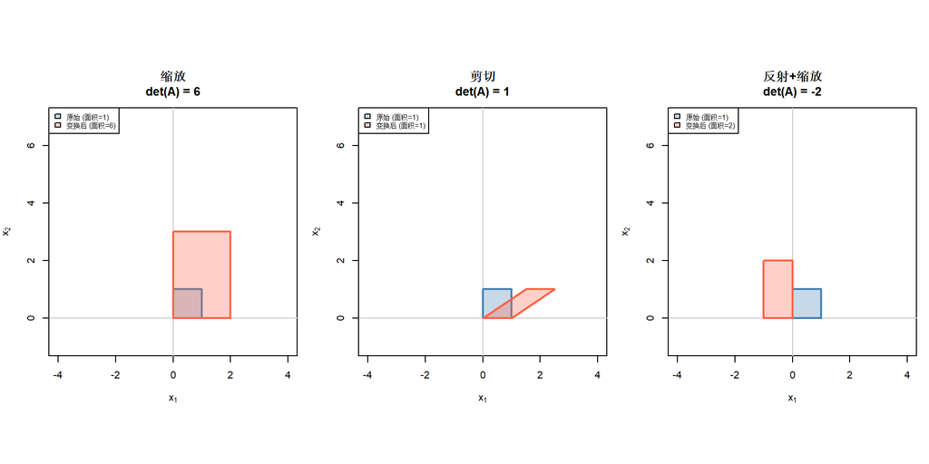

```r
matrices <- list(
  "缩放" = matrix(c(2, 0, 0, 3), 2, byrow = TRUE),
  "剪切" = matrix(c(1, 1.5, 0, 1), 2, byrow = TRUE),
  "反射+缩放" = matrix(c(-1, 0, 0, 2), 2, byrow = TRUE)
)

# 单位正方形
sq <- matrix(c(0,0, 1,0, 1,1, 0,1, 0,0), nrow = 2)

par(mfrow = c(1, 3), pty = "s", mar = c(4, 4, 4, 1))
for (nm in names(matrices)) {
  A <- matrices[[nm]]
  d <- det(A)
  sq_t <- A %*% sq

  plot(NULL, xlim = c(-4, 4), ylim = c(-1, 7), asp = 1,
       xlab = expression(x[1]), ylab = expression(x[2]),
       main = paste0(nm, "\ndet(A) = ", round(d, 2)))
  abline(h = 0, v = 0, col = "gray80")
  polygon(sq[1, ], sq[2, ], col = adjustcolor("steelblue", 0.3), border = "steelblue", lwd = 2)
  polygon(sq_t[1, ], sq_t[2, ], col = adjustcolor("tomato", 0.3), border = "tomato", lwd = 2)
  legend("topleft", c("原始 (面积=1)", paste0("变换后 (面积=", abs(round(d, 2)), ")")),
         fill = c(adjustcolor("steelblue", 0.3), adjustcolor("tomato", 0.3)),
         cex = 0.7)
}
```

**观察**：变换后平行四边形的面积恰好等于 $|\det(A)|$ 乘以原面积。反射变换（$\det < 0$）时，图形的”手性”发生了翻转。

## 2.5 实验 1.5 —— 主动视角与被动视角

同一个矩阵 $A$ 可以有两种解读：**主动视角**认为 $A$ 把向量 $x$ 变成了新向量 $Ax$；**被动视角**认为向量不变，是坐标系变了，$A^{-1}x$ 是同一个向量在新基下的坐标。

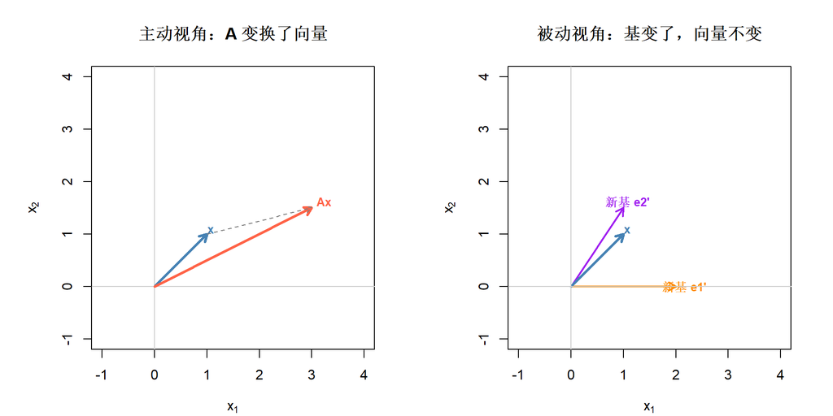

```r
A <- matrix(c(2, 1,
              0, 1.5), nrow = 2, byrow = TRUE)
x <- c(1, 1)
Ax <- A %*% x
A_inv <- solve(A)
x_new_basis <- A_inv %*% x

par(mfrow = c(1, 2), pty = "s", mar = c(4, 4, 4, 1))

# 主动视角
plot(NULL, xlim = c(-1, 4), ylim = c(-1, 4), asp = 1,
     xlab = expression(x[1]), ylab = expression(x[2]),
     main = "主动视角：A 变换了向量")
abline(h = 0, v = 0, col = "gray80")
draw_vector(x, col = "steelblue", lwd = 3, label = "x")
draw_vector(as.numeric(Ax), col = "tomato", lwd = 3, label = "Ax")
arrows(x[1], x[2], Ax[1], Ax[2], col = "gray50", lwd = 1, lty = 2, length = 0.08)

# 被动视角
plot(NULL, xlim = c(-1, 4), ylim = c(-1, 4), asp = 1,
     xlab = expression(x[1]), ylab = expression(x[2]),
     main = "被动视角：基变了，向量不变")
# 画新基向量
draw_vector(A[, 1], col = "darkorange", lwd = 2, label = "新基 e1'")
draw_vector(A[, 2], col = "purple", lwd = 2, label = "新基 e2'")
draw_vector(x, col = "steelblue", lwd = 3, label = "x")
abline(h = 0, v = 0, col = "gray80")
```

```r
cat("x 在标准基下的坐标：", x, "\n")
```

```
x 在标准基下的坐标： 1 1
```

```r
cat("x 在新基 A 下的坐标：", round(as.numeric(x_new_basis), 4), "\n")
```

```
x 在新基 A 下的坐标： 0.1667 0.6667
```

**理解**：左图中，$x$ 被 $A$ “搬到了”新位置；右图中，同一个向量 $x$ 在新基（$A$ 的列向量）下的坐标变为 $A^{-1}x$。两种视角数学上等价，但直觉不同。

# 3 第二章：特征值与特征向量

## 3.1 实验 2.1 —— R 中计算特征值和特征向量

$Ax = \lambda x$：矩阵 $A$ 作用于特征向量 $x$ 时，$x$ 的方向不变，只被缩放 $\lambda$ 倍。

```r
A <- matrix(c(4, 1,
              2, 3), nrow = 2, byrow = TRUE)

eig <- eigen(A)
cat("特征值：", eig$values, "\n")
```

```
特征值： 5 2
```

```r
cat("特征向量（列向量）：\n"); print(round(eig$vectors, 4))
```

```
特征向量（列向量）：
```

```
       [,1]    [,2]
[1,] 0.7071 -0.4472
[2,] 0.7071  0.8944
```

```r
# 验证 Ax = λx
for (i in 1:2) {
  v <- eig$vectors[, i]
  lam <- eig$values[i]
  Av <- A %*% v
  lam_v <- lam * v
  cat(sprintf("特征值 λ%d = %.4f | Av = (%.4f, %.4f) | λv = (%.4f, %.4f) | 匹配：%s\n",
              i, lam, Av[1], Av[2], lam_v[1], lam_v[2],
              all.equal(as.numeric(Av), lam_v)))
}
```

```
特征值 λ1 = 5.0000 | Av = (3.5355, 3.5355) | λv = (3.5355, 3.5355) | 匹配：TRUE
特征值 λ2 = 2.0000 | Av = (-0.8944, 1.7889) | λv = (-0.8944, 1.7889) | 匹配：TRUE
```

## 3.2 实验 2.2 —— 可视化：特征向量在变换下只被拉伸

对单位圆上的所有方向施加矩阵 $A$，观察哪些方向在变换后仍保持方向不变。

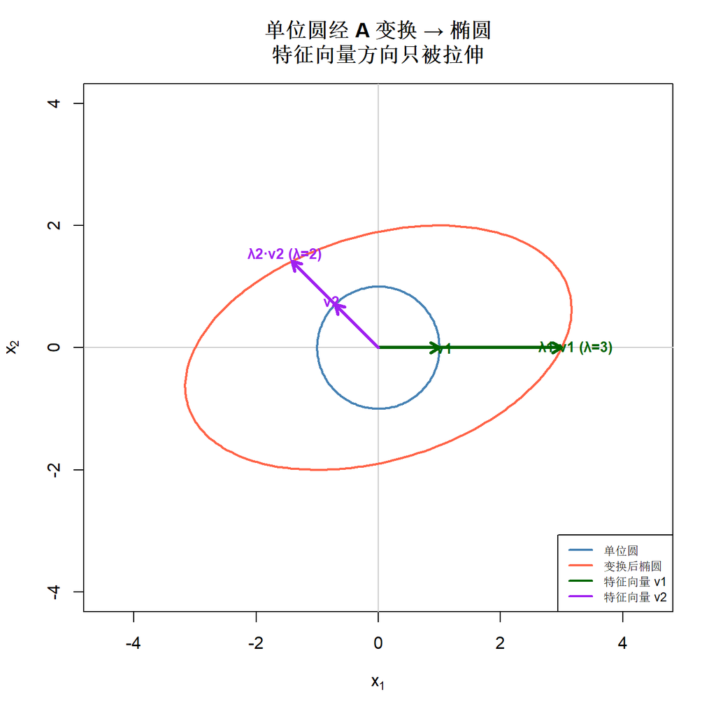

```r
A <- matrix(c(3, 1,
              0, 2), nrow = 2, byrow = TRUE)
eig <- eigen(A)

theta <- seq(0, 2 * pi, length.out = 200)
circle <- rbind(cos(theta), sin(theta))
ellipse <- A %*% circle

plot(NULL, xlim = c(-4, 4), ylim = c(-4, 4), asp = 1,
     xlab = expression(x[1]), ylab = expression(x[2]),
     main = "单位圆经 A 变换 → 椭圆\n特征向量方向只被拉伸")
abline(h = 0, v = 0, col = "gray80")

lines(circle[1, ], circle[2, ], col = "steelblue", lwd = 2)
lines(ellipse[1, ], ellipse[2, ], col = "tomato", lwd = 2)

# 画特征向量和变换后的特征向量
cols_eig <- c("darkgreen", "purple")
for (i in 1:2) {
  v <- eig$vectors[, i]
  lam <- eig$values[i]
  # 原特征方向（单位向量在圆上）
  draw_vector(v, col = cols_eig[i], lwd = 3,
              label = paste0("v", i))
  # 变换后 = λ * v（在椭圆上）
  draw_vector(lam * v, col = cols_eig[i], lwd = 3,
              label = paste0("λ", i, "·v", i, " (λ=", round(lam, 2), ")"))
}

legend("bottomright",
       c("单位圆", "变换后椭圆", "特征向量 v1", "特征向量 v2"),
       col = c("steelblue", "tomato", cols_eig),
       lwd = 2, cex = 0.75)
```

**观察**：绿色和紫色箭头从圆到椭圆，方向没有改变，只是长度按 $\lambda$ 倍缩放——这正是特征向量的定义。

## 3.3 实验 2.3 —— 特征空间

特征空间 $E_\lambda = \{x : Ax = \lambda x\}$ 是对应特征值 $\lambda$ 的所有特征向量（加上零向量）构成的子空间。

```r
# 一个有重复特征值的矩阵
A <- matrix(c(2, 1,
              0, 2), nrow = 2, byrow = TRUE)
eig <- eigen(A)
cat("特征值：", eig$values, "\n")
```

```
特征值： 2 2
```

```r
cat("特征向量：\n"); print(eig$vectors)
```

```
特征向量：
```

```
     [,1]          [,2]
[1,]    1 -1.000000e+00
[2,]    0  4.440892e-16
```

```r
cat("\n这个矩阵的特征值 λ=2 是重根（代数重数=2），但几何重数=1\n")
```

```
这个矩阵的特征值 λ=2 是重根（代数重数=2），但几何重数=1
```

```r
cat("特征空间 E_2 只是一条直线，不能张成整个 R^2\n")
```

```
特征空间 E_2 只是一条直线，不能张成整个 R^2
```

```r
cat("因此该矩阵不可对角化\n\n")
```

```
因此该矩阵不可对角化
```

```r
# 可对角化的例子
B <- matrix(c(3, 0,
              0, 3), nrow = 2, byrow = TRUE)
eig_B <- eigen(B)
cat("B 的特征值：", eig_B$values, "\n")
```

```
B 的特征值： 3 3
```

```r
cat("B 的特征向量：\n"); print(eig_B$vectors)
```

```
B 的特征向量：
```

```
     [,1] [,2]
[1,]    0   -1
[2,]    1    0
```

```r
cat("B = 3I，每个方向都是特征向量，E_3 = R^2，维数 = 2\n")
```

```
B = 3I，每个方向都是特征向量，E_3 = R^2，维数 = 2
```

```r
cat("B 可以对角化（本身就是对角矩阵）\n")
```

```
B 可以对角化（本身就是对角矩阵）
```

## 3.4 实验 2.4 —— 矩阵对角化：$A = P \Lambda P^{-1}$

如果 $A$ 有 $n$ 个线性无关的特征向量，就可以对角化。

```r
A <- matrix(c(4, 1,
              2, 3), nrow = 2, byrow = TRUE)

eig <- eigen(A)
P <- eig$vectors
Lambda <- diag(eig$values)
P_inv <- solve(P)

cat("P（特征向量矩阵）：\n"); print(round(P, 4))
```

```
P（特征向量矩阵）：
```

```
       [,1]    [,2]
[1,] 0.7071 -0.4472
[2,] 0.7071  0.8944
```

```r
cat("\nΛ（特征值对角矩阵）：\n"); print(round(Lambda, 4))
```

```
Λ（特征值对角矩阵）：
```

```
     [,1] [,2]
[1,]    5    0
[2,]    0    2
```

```r
# 验证 A = P Λ P^{-1}
A_reconstructed <- P %*% Lambda %*% P_inv
cat("\nP Λ P^{-1} =\n"); print(round(A_reconstructed, 10))
```

```
P Λ P^{-1} =
```

```
     [,1] [,2]
[1,]    4    1
[2,]    2    3
```

```r
cat("\n原始 A =\n"); print(A)
```

```
原始 A =
```

```
     [,1] [,2]
[1,]    4    1
[2,]    2    3
```

```r
cat("\n重构误差：", max(abs(A - A_reconstructed)), "\n")
```

```
重构误差： 8.881784e-16
```

```r
# 验证 det(A) = det(Λ) = λ1 * λ2
cat("\ndet(A) =", det(A), "\n")
```

```
det(A) = 10
```

```r
cat("λ1 × λ2 =", prod(eig$values), "\n")
```

```
λ1 × λ2 = 10
```

## 3.5 实验 2.5 —— 矩阵幂：$A^k = P \Lambda^k P^{-1}$

对角化的强大之处在于矩阵幂的计算变得极其简单。

```r
A <- matrix(c(1.2, 0.3,
              0.1, 0.9), nrow = 2, byrow = TRUE)
eig <- eigen(A)
P <- eig$vectors
P_inv <- solve(P)

k <- 10

# 方法 1：直接连乘
A_power_direct <- diag(2)
for (i in 1:k) A_power_direct <- A_power_direct %*% A

# 方法 2：P Λ^k P^{-1}
Lambda_k <- diag(eig$values^k)
A_power_eig <- P %*% Lambda_k %*% P_inv

cat("直接计算 A^10 =\n"); print(round(A_power_direct, 6))
```

```
直接计算 A^10 =
```

```
         [,1]     [,2]
[1,] 9.725061 7.585401
[2,] 2.528467 2.139661
```

```r
cat("\nP Λ^10 P^{-1} =\n"); print(round(A_power_eig, 6))
```

```
P Λ^10 P^{-1} =
```

```
         [,1]     [,2]
[1,] 9.725061 7.585401
[2,] 2.528467 2.139661
```

```r
cat("\n误差：", max(abs(A_power_direct - A_power_eig)), "\n")
```

```
误差： 1.065814e-14
```

```r
# 可视化 A^k 的效果
cat("\n随着 k 增大，A^k 的行为取决于特征值的绝对值：\n")
```

```
随着 k 增大，A^k 的行为取决于特征值的绝对值：
```

```r
cat("  λ1 =", round(eig$values[1], 4), " |λ1| =", round(abs(eig$values[1]), 4), "\n")
```

```
  λ1 = 1.2791  |λ1| = 1.2791
```

```r
cat("  λ2 =", round(eig$values[2], 4), " |λ2| =", round(abs(eig$values[2]), 4), "\n")
```

```
  λ2 = 0.8209  |λ2| = 0.8209
```

```r
cat("如果 |λ| < 1，该方向收缩；|λ| > 1，该方向膨胀；|λ| = 1，不变。\n")
```

```
如果 |λ| < 1，该方向收缩；|λ| > 1，该方向膨胀；|λ| = 1，不变。
```

## 3.6 实验 2.6 —— 特征基下的坐标变换

把向量 $x$ 变换到特征基下后，矩阵 $A$ 的作用变成了简单的对角缩放。

```r
A <- matrix(c(3, 1,
              1, 3), nrow = 2, byrow = TRUE)
eig <- eigen(A)
B <- eig$vectors     # 特征基矩阵
B_inv <- solve(B)

x <- c(2, 1)

# 标准基下的坐标和变换
Ax <- A %*% x

# 特征基下的坐标
x_B <- B_inv %*% x
Ax_B <- B_inv %*% Ax

# A 在特征基下的矩阵表示
A_B <- B_inv %*% A %*% B   # 应为对角矩阵

cat("x 在标准基下 =", x, "\n")
```

```
x 在标准基下 = 2 1
```

```r
cat("x 在特征基下 =", round(as.numeric(x_B), 4), "\n")
```

```
x 在特征基下 = 2.1213 -0.7071
```

```r
cat("\nA 在特征基下的矩阵 [A]_B =\n"); print(round(A_B, 4))
```

```
A 在特征基下的矩阵 [A]_B =
```

```
     [,1] [,2]
[1,]    4    0
[2,]    0    2
```

```r
cat("（是对角矩阵！在特征基下 A 只是简单的缩放）\n")
```

```
（是对角矩阵！在特征基下 A 只是简单的缩放）
```

```r
cat("\nAx 在标准基下 =", as.numeric(Ax), "\n")
```

```
Ax 在标准基下 = 7 5
```

```r
cat("Ax 在特征基下 =", round(as.numeric(Ax_B), 4), "\n")
```

```
Ax 在特征基下 = 8.4853 -1.4142
```

```r
cat("[A]_B · [x]_B  =", round(as.numeric(A_B %*% x_B), 4), "\n")
```

```
[A]_B · [x]_B  = 8.4853 -1.4142
```

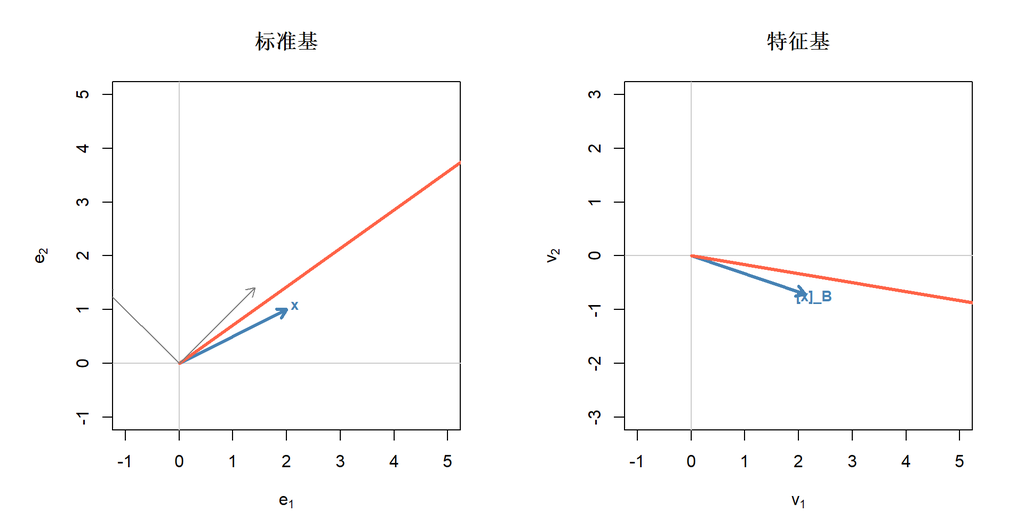

```r
par(mfrow = c(1, 2), pty = "s", mar = c(4, 4, 4, 1))

# 标准基视角
plot(NULL, xlim = c(-1, 5), ylim = c(-1, 5), asp = 1,
     main = "标准基", xlab = expression(e[1]), ylab = expression(e[2]))
abline(h = 0, v = 0, col = "gray80")
draw_vector(x, col = "steelblue", lwd = 3, label = "x")
draw_vector(as.numeric(Ax), col = "tomato", lwd = 3, label = "Ax")
for (i in 1:2) {
  draw_vector(eig$vectors[, i] * 2, col = "gray50", lwd = 1)
}

# 特征基视角
plot(NULL, xlim = c(-1, 5), ylim = c(-3, 3), asp = 1,
     main = "特征基", xlab = expression(v[1]), ylab = expression(v[2]))
abline(h = 0, v = 0, col = "gray80")
draw_vector(as.numeric(x_B), col = "steelblue", lwd = 3, label = "[x]_B")
draw_vector(as.numeric(Ax_B), col = "tomato", lwd = 3, label = "[Ax]_B")
```

**理解**：在特征基下，$A$ 变成了对角矩阵，变换不再”混合”不同方向，每个坐标轴独立地被对应的特征值缩放。

# 4 第三章：正交与投影

## 4.1 实验 3.1 —— 内积、范数与夹角

内积 $\langle v, w \rangle = v^T w$ 连接了长度、角度和正交性这三个核心概念。

```r
v <- c(3, 1)
w <- c(1, 2)

# 内积
inner <- sum(v * w)   # 等价于 t(v) %*% w
cat("v =", v, "\n")
```

```
v = 3 1
```

```r
cat("w =", w, "\n")
```

```
w = 1 2
```

```r
cat("<v, w> =", inner, "\n")
```

```
<v, w> = 5
```

```r
# 范数
norm_v <- vnorm(v)
norm_w <- vnorm(w)
cat("||v|| =", round(norm_v, 4), "\n")
```

```
||v|| = 3.1623
```

```r
cat("||w|| =", round(norm_w, 4), "\n")
```

```
||w|| = 2.2361
```

```r
# 夹角
cos_theta <- inner / (norm_v * norm_w)
theta <- acos(cos_theta) * 180 / pi
cat("cos(θ) =", round(cos_theta, 4), "\n")
```

```
cos(θ) = 0.7071
```

```r
cat("θ =", round(theta, 2), "°\n")
```

```
θ = 45 °
```

```r
# 柯西-施瓦茨不等式
cat("\n柯西-施瓦茨不等式验证：\n")
```

```
柯西-施瓦茨不等式验证：
```

```r
cat("|<v,w>| =", abs(inner), " ≤ ||v||·||w|| =", round(norm_v * norm_w, 4), "\n")
```

```
|<v,w>| = 5  ≤ ||v||·||w|| = 7.0711
```

```r
# 勾股定理（只有正交向量才成立）
u1 <- c(1, 0)
u2 <- c(0, 2)
cat("\n正交向量 u1 =", u1, ", u2 =", u2, "\n")
```

```
正交向量 u1 = 1 0 , u2 = 0 2
```

```r
cat("||u1+u2||² =", vnorm(u1 + u2)^2, "\n")
```

```
||u1+u2||² = 5
```

```r
cat("||u1||² + ||u2||² =", vnorm(u1)^2 + vnorm(u2)^2, "\n")
```

```
||u1||² + ||u2||² = 5
```

## 4.2 实验 3.2 —— 正交矩阵：旋转变换

正交矩阵 $U$ 满足 $U^T U = I$，变换后向量长度不变。几何上它是旋转（或旋转+反射）。

```r
# 旋转矩阵（旋转 45°）
angle <- pi / 4
U <- matrix(c(cos(angle), sin(angle),
             -sin(angle), cos(angle)), nrow = 2, byrow = TRUE)

cat("U =\n"); print(round(U, 4))
```

```
U =
```

```
        [,1]   [,2]
[1,]  0.7071 0.7071
[2,] -0.7071 0.7071
```

```r
cat("\nU^T U =\n"); print(round(t(U) %*% U, 10))
```

```
U^T U =
```

```
     [,1] [,2]
[1,]    1    0
[2,]    0    1
```

```r
cat("det(U) =", round(det(U), 4), "\n")
```

```
det(U) = 1
```

```r
# 验证长度不变
x <- c(3, 1)
Ux <- U %*% x
cat("\n||x|| =", round(vnorm(x), 4), "\n")
```

```
||x|| = 3.1623
```

```r
cat("||Ux|| =", round(vnorm(as.numeric(Ux)), 4), "\n")
```

```
||Ux|| = 3.1623
```

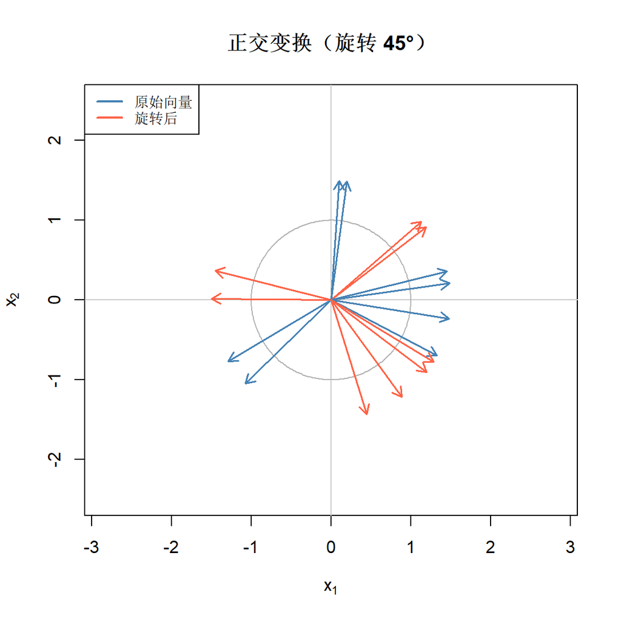

```r
# 可视化旋转
circ <- unit_circle()
circ_rot <- U %*% circ

plot(NULL, xlim = c(-2.5, 2.5), ylim = c(-2.5, 2.5), asp = 1,
     main = paste0("正交变换（旋转 ", round(angle * 180 / pi), "°）"),
     xlab = expression(x[1]), ylab = expression(x[2]))
abline(h = 0, v = 0, col = "gray80")
lines(circ[1, ], circ[2, ], col = "gray70", lwd = 1)

# 随机生成一些方向向量
set.seed(7)
test_vecs <- matrix(rnorm(2 * 8), nrow = 2)
for (j in 1:ncol(test_vecs)) {
  test_vecs[, j] <- test_vecs[, j] / vnorm(test_vecs[, j]) * 1.5
}

for (j in 1:ncol(test_vecs)) {
  v <- test_vecs[, j]
  Uv <- as.numeric(U %*% v)
  draw_vector(v, col = "steelblue", lwd = 1.5)
  draw_vector(Uv, col = "tomato", lwd = 1.5)
}
legend("topleft", c("原始向量", "旋转后"),
       col = c("steelblue", "tomato"), lwd = 2, cex = 0.8)
```

**观察**：所有向量旋转了相同的角度，长度完全不变。正交矩阵保持了内积结构：长度不变，夹角不变。

## 4.3 实验 3.3 —— 向量投影

向量 $v$ 在方向 $u$ 上的投影为 $\hat{v} = \frac{\langle v, u \rangle}{\langle u, u \rangle} u$，残差 $z = v - \hat{v}$ 与 $u$ 正交。

```r
v <- c(3, 2)
u <- c(4, 1)

# 投影
c_proj <- sum(v * u) / sum(u * u)
v_hat <- c_proj * u
z <- v - v_hat

cat("v =", v, "\n")
```

```
v = 3 2
```

```r
cat("u =", u, "\n")
```

```
u = 4 1
```

```r
cat("投影系数 c =", round(c_proj, 4), "\n")
```

```
投影系数 c = 0.8235
```

```r
cat("投影 v̂ =", round(v_hat, 4), "\n")
```

```
投影 v̂ = 3.2941 0.8235
```

```r
cat("残差 z =", round(z, 4), "\n")
```

```
残差 z = -0.2941 1.1765
```

```r
cat("验证正交：<z, u> =", round(sum(z * u), 10), "\n")
```

```
验证正交：<z, u> = 0
```

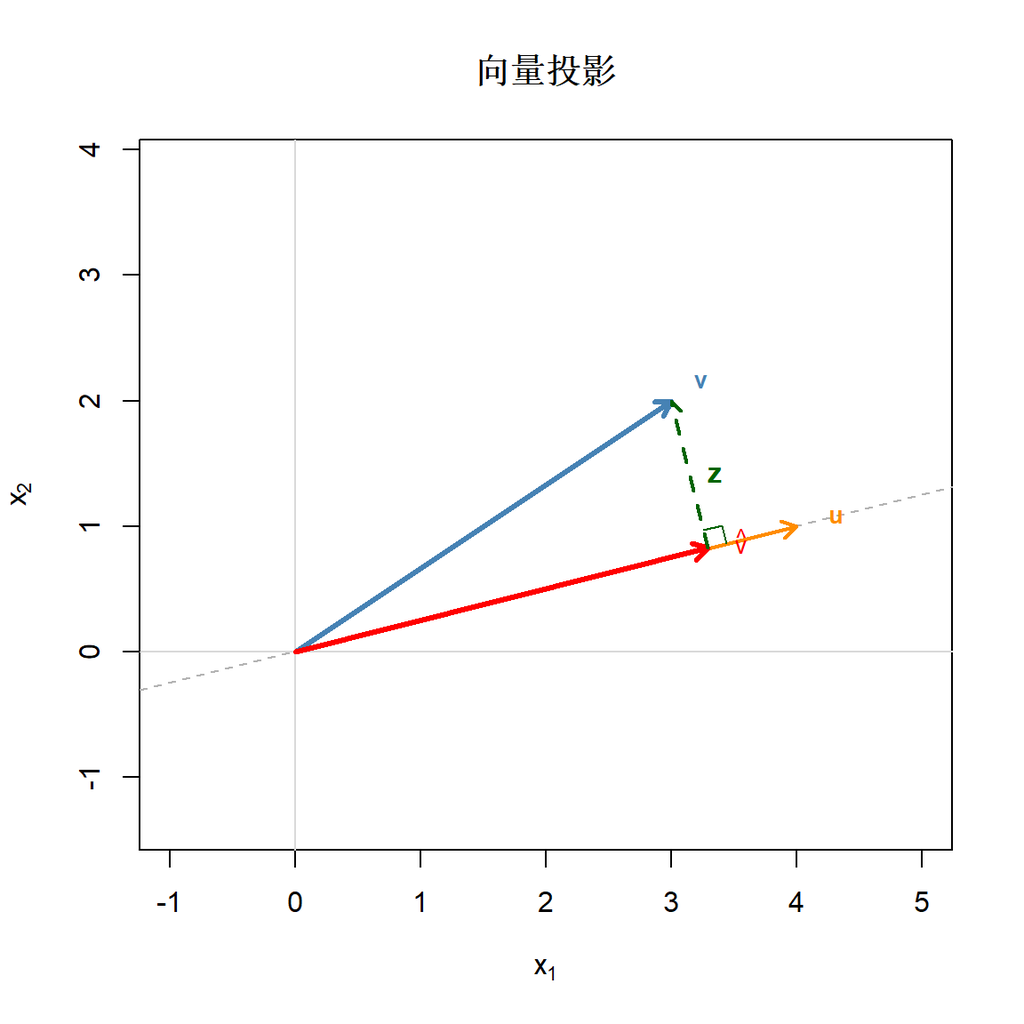

```r
plot(NULL, xlim = c(-1, 5), ylim = c(-1, 3.5), asp = 1,
     main = "向量投影", xlab = expression(x[1]), ylab = expression(x[2]))
abline(h = 0, v = 0, col = "gray85")
# 投影方向线
abline(0, u[2]/u[1], col = "gray70", lty = 2)
draw_vector(u, col = "darkorange", lwd = 2, label = "u")
draw_vector(v, col = "steelblue", lwd = 3, label = "v")
draw_vector(v_hat, col = "red", lwd = 3, label = expression(hat(v)))
# 残差
arrows(v_hat[1], v_hat[2], v[1], v[2], col = "darkgreen", lwd = 2,
       length = 0.08, lty = 2)
text((v[1] + v_hat[1])/2 + 0.2, (v[2] + v_hat[2])/2, "z", col = "darkgreen", font = 2)
# 直角标记
sq_size <- 0.15
sq_dir <- z / vnorm(z) * sq_size
sq_perp <- v_hat / vnorm(v_hat) * sq_size
lines(v_hat[1] + c(sq_dir[1], sq_dir[1] + sq_perp[1], sq_perp[1]),
      v_hat[2] + c(sq_dir[2], sq_dir[2] + sq_perp[2], sq_perp[2]),
      col = "darkgreen")
```

## 4.4 实验 3.4 —— Gram-Schmidt 正交化

从任意线性无关的向量组出发，Gram-Schmidt 过程逐步构造出正交（规范正交）基。

```r
# 原始基（非正交）
v1 <- c(3, 1)
v2 <- c(2, 2)

# Gram-Schmidt 第一步：u1 = v1
u1 <- v1

# 第二步：u2 = v2 - proj_{u1}(v2)
proj_coeff <- sum(v2 * u1) / sum(u1 * u1)
u2 <- v2 - proj_coeff * u1

# 归一化
w1 <- u1 / vnorm(u1)
w2 <- u2 / vnorm(u2)

cat("原始基：v1 =", v1, ", v2 =", v2, "\n")
```

```
原始基：v1 = 3 1 , v2 = 2 2
```

```r
cat("正交基：u1 =", round(u1, 4), ", u2 =", round(u2, 4), "\n")
```

```
正交基：u1 = 3 1 , u2 = -0.4 1.2
```

```r
cat("验证正交：<u1, u2> =", round(sum(u1 * u2), 10), "\n")
```

```
验证正交：<u1, u2> = 0
```

```r
cat("规范正交基：w1 =", round(w1, 4), ", w2 =", round(w2, 4), "\n")
```

```
规范正交基：w1 = 0.9487 0.3162 , w2 = -0.3162 0.9487
```

```r
cat("验证：<w1,w1>=", round(sum(w1*w1), 4),
    ", <w2,w2>=", round(sum(w2*w2), 4),
    ", <w1,w2>=", round(sum(w1*w2), 10), "\n")
```

```
验证：<w1,w1>= 1 , <w2,w2>= 1 , <w1,w2>= 0
```

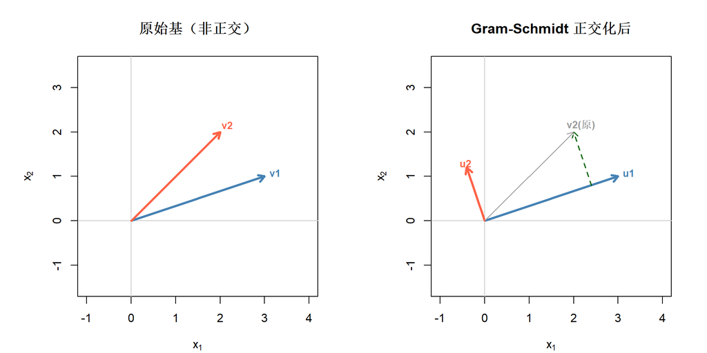

```r
par(mfrow = c(1, 2), pty = "s", mar = c(4, 4, 4, 1))

# 原始基
plot(NULL, xlim = c(-1, 4), ylim = c(-1, 3), asp = 1,
     main = "原始基（非正交）", xlab = expression(x[1]), ylab = expression(x[2]))
abline(h = 0, v = 0, col = "gray80")
draw_vector(v1, col = "steelblue", lwd = 3, label = "v1")
draw_vector(v2, col = "tomato", lwd = 3, label = "v2")

# 正交化后
plot(NULL, xlim = c(-1, 4), ylim = c(-1, 3), asp = 1,
     main = "Gram-Schmidt 正交化后", xlab = expression(x[1]), ylab = expression(x[2]))
abline(h = 0, v = 0, col = "gray80")
draw_vector(u1, col = "steelblue", lwd = 3, label = "u1")
draw_vector(u2, col = "tomato", lwd = 3, label = "u2")
# 显示投影过程
draw_vector(v2, col = "gray60", lwd = 1, label = "v2(原)")
arrows(proj_coeff * u1[1], proj_coeff * u1[2], v2[1], v2[2],
       col = "darkgreen", lwd = 1.5, lty = 2, length = 0.08)
```

## 4.5 实验 3.5 —— 最小二乘法

当方程组 $Ax = b$ 无精确解时，最小二乘找到使 $\|Ax - b\|$ 最小的 $\hat{x} = (A^T A)^{-1} A^T b$。

```r
# 生成带噪声的数据：y ≈ 2 + 3x
set.seed(42)
n <- 30
x_data <- runif(n, 0, 5)
y_data <- 2 + 3 * x_data + rnorm(n, sd = 2)

# 构造设计矩阵（含截距列）
A <- cbind(1, x_data)

# 最小二乘公式
beta_hat <- solve(t(A) %*% A) %*% t(A) %*% y_data
cat("最小二乘估计：β̂ =", round(beta_hat, 4), "\n")
```

```
最小二乘估计：β̂ = 1.9135 2.8037
```

```r
cat("（截距 ≈", round(beta_hat[1], 2), "，斜率 ≈", round(beta_hat[2], 2), "）\n")
```

```
（截距 ≈ 1.91 ，斜率 ≈ 2.8 ）
```

```r
# 拟合值和残差
y_hat <- A %*% beta_hat
residuals <- y_data - y_hat
cat("残差平方和 ||Ax̂ - b||² =", round(sum(residuals^2), 4), "\n")
```

```
残差平方和 ||Ax̂ - b||² = 156.376
```

```r
# 验证：残差与列空间正交
cat("验证残差正交于 A 的列：\n")
```

```
验证残差正交于 A 的列：
```

```r
cat("  A^T · 残差 =", round(as.numeric(t(A) %*% residuals), 10), "\n")
```

```
  A^T · 残差 = 0 0
```

```r
# 与 R 内置函数对比
fit <- lm(y_data ~ x_data)
cat("\nlm() 结果：截距 =", round(coef(fit)[1], 4),
    "，斜率 =", round(coef(fit)[2], 4), "\n")
```

```
lm() 结果：截距 = 1.9135 ，斜率 = 2.8037
```

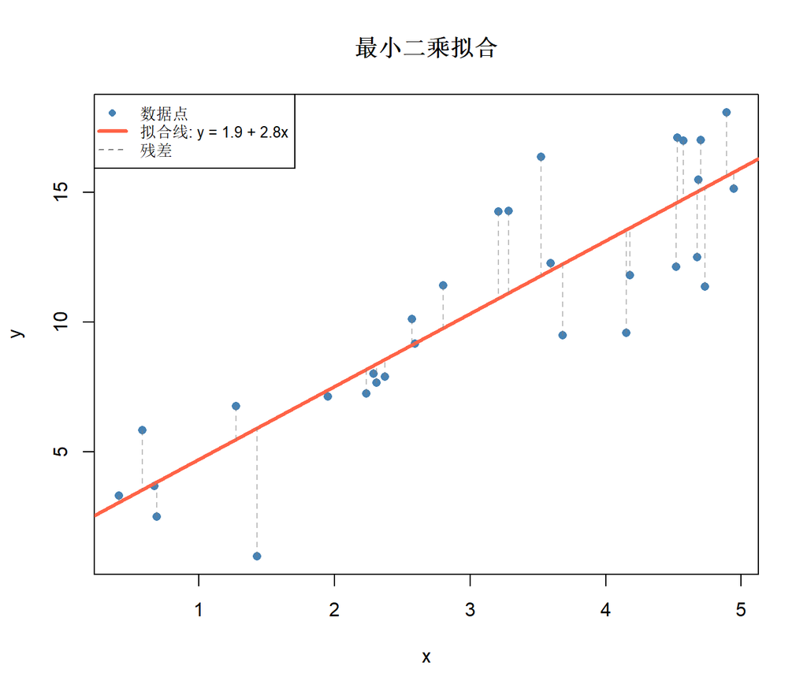

```r
# 可视化
plot(x_data, y_data, pch = 16, col = "steelblue",
     xlab = "x", ylab = "y", main = "最小二乘拟合")
abline(beta_hat[1], beta_hat[2], col = "tomato", lwd = 3)
segments(x_data, y_data, x_data, y_hat, col = adjustcolor("gray50", 0.5), lty = 2)
legend("topleft",
       c("数据点", paste0("拟合线: y = ", round(beta_hat[1],1), " + ",
                         round(beta_hat[2],1), "x"), "残差"),
       pch = c(16, NA, NA), lty = c(NA, 1, 2),
       col = c("steelblue", "tomato", "gray50"), lwd = c(NA, 3, 1), cex = 0.8)
```

**理解**：最小二乘的几何本质是将 $b$ 投影到 $\text{Col}(A)$ 上，投影 $\hat{b} = A\hat{x}$ 是列空间中距离 $b$ 最近的点，残差 $b - \hat{b}$ 与列空间正交。

## 4.6 实验 3.6 —— 正交对角化与谱分解

对称矩阵 $A = P \Lambda P^T$ 可以展开为 $A = \sum_{i=1}^n \lambda_i p_i p_i^T$，每一项是一个在特征方向上的加权投影。

```r
A <- matrix(c(5, 2,
              2, 2), nrow = 2, byrow = TRUE)
cat("A =\n"); print(A)
```

```
A =
```

```
     [,1] [,2]
[1,]    5    2
[2,]    2    2
```

```r
cat("A 是对称的：", all(A == t(A)), "\n\n")
```

```
A 是对称的： TRUE
```

```r
eig <- eigen(A)
P <- eig$vectors
Lambda <- diag(eig$values)

# 验证正交对角化 A = P Λ P^T
A_recon <- P %*% Lambda %*% t(P)
cat("P Λ P^T =\n"); print(round(A_recon, 10))
```

```
P Λ P^T =
```

```
     [,1] [,2]
[1,]    5    2
[2,]    2    2
```

```r
cat("\n验证 P 正交：P^T P =\n"); print(round(t(P) %*% P, 10))
```

```
验证 P 正交：P^T P =
```

```
     [,1] [,2]
[1,]    1    0
[2,]    0    1
```

```r
# 谱分解：A = λ1 p1 p1^T + λ2 p2 p2^T
p1 <- P[, 1, drop = FALSE]
p2 <- P[, 2, drop = FALSE]
term1 <- eig$values[1] * (p1 %*% t(p1))
term2 <- eig$values[2] * (p2 %*% t(p2))
cat("\n谱分解：\n")
```

```
谱分解：
```

```r
cat("λ1·p1·p1^T =\n"); print(round(term1, 4))
```

```
λ1·p1·p1^T =
```

```
     [,1] [,2]
[1,]  4.8  2.4
[2,]  2.4  1.2
```

```r
cat("λ2·p2·p2^T =\n"); print(round(term2, 4))
```

```
λ2·p2·p2^T =
```

```
     [,1] [,2]
[1,]  0.2 -0.4
[2,] -0.4  0.8
```

```r
cat("和 =\n"); print(round(term1 + term2, 10))
```

```
和 =
```

```
     [,1] [,2]
[1,]    5    2
[2,]    2    2
```

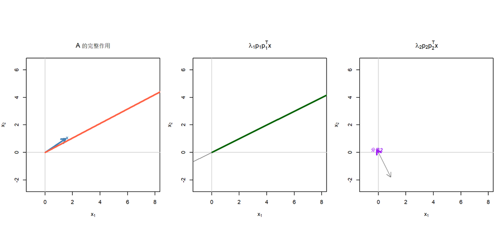

```r
# 可视化谱分解对向量的作用
par(mfrow = c(1, 3), pty = "s", mar = c(4, 4, 4, 1))
x <- c(1.5, 1)
Ax <- A %*% x

plot(NULL, xlim = c(-1, 8), ylim = c(-2, 6), asp = 1,
     main = expression("A 的完整作用"), xlab = expression(x[1]), ylab = expression(x[2]))
abline(h = 0, v = 0, col = "gray80")
draw_vector(x, col = "steelblue", lwd = 3, label = "x")
draw_vector(as.numeric(Ax), col = "tomato", lwd = 3, label = "Ax")

# 分解为两个分量
comp1 <- as.numeric(term1 %*% x)
comp2 <- as.numeric(term2 %*% x)

plot(NULL, xlim = c(-1, 8), ylim = c(-2, 6), asp = 1,
     main = expression(lambda[1] * p[1] * p[1]^T * x), xlab = expression(x[1]), ylab = expression(x[2]))
abline(h = 0, v = 0, col = "gray80")
draw_vector(comp1, col = "darkgreen", lwd = 3, label = "分量1")
draw_vector(as.numeric(P[, 1]) * 2, col = "gray50", lwd = 1)

plot(NULL, xlim = c(-1, 8), ylim = c(-2, 6), asp = 1,
     main = expression(lambda[2] * p[2] * p[2]^T * x), xlab = expression(x[1]), ylab = expression(x[2]))
abline(h = 0, v = 0, col = "gray80")
draw_vector(comp2, col = "purple", lwd = 3, label = "分量2")
draw_vector(as.numeric(P[, 2]) * 2, col = "gray50", lwd = 1)
```

**理解**：$Ax$ 等于先把 $x$ 投影到每个特征方向上，再按对应的特征值缩放，最后叠加——这就是谱分解的几何含义。

# 5 第四章：二次型

## 5.1 实验 4.1 —— 二次型的矩阵表示

二次型 $Q(x) = x^T A x$ 将向量映射为标量。它衡量了向量 $x$ 与变换后向量 $Ax$ 的”同向程度”。

```r
# f(x,y) = 5x^2 + 4xy + 2y^2
# 对称矩阵形式：交叉项 4xy 拆为 2·2·xy
A <- matrix(c(5, 2,
              2, 2), nrow = 2, byrow = TRUE)

x <- c(1, 2)

# 方法 1：直接计算
Q_direct <- 5 * x[1]^2 + 4 * x[1] * x[2] + 2 * x[2]^2

# 方法 2：矩阵形式 x^T A x
Q_matrix <- t(x) %*% A %*% x

cat("f(1, 2) = 5(1)² + 4(1)(2) + 2(2)² =", Q_direct, "\n")
```

```
f(1, 2) = 5(1)² + 4(1)(2) + 2(2)² = 21
```

```r
cat("x^T A x =", as.numeric(Q_matrix), "\n")
```

```
x^T A x = 21
```

```r
cat("A 是对称的：", all(A == t(A)), "\n")
```

```
A 是对称的： TRUE
```

```r
# 二次型的符号与夹角
Ax <- A %*% x
cos_angle <- sum(x * Ax) / (vnorm(x) * vnorm(as.numeric(Ax)))
angle_deg <- acos(cos_angle) * 180 / pi
cat("\n几何解读：\n")
```

```
几何解读：
```

```r
cat("x 与 Ax 的夹角 =", round(angle_deg, 2), "°\n")
```

```
x 与 Ax 的夹角 = 29.74 °
```

```r
cat("Q(x) > 0，说明 x 和 Ax 夹角是锐角（同向趋势）\n")
```

```
Q(x) > 0，说明 x 和 Ax 夹角是锐角（同向趋势）
```

## 5.2 实验 4.2 —— 二次型曲面可视化

不同类型的对称矩阵产生不同形状的二次曲面。特征值的正负决定了曲面的类型。

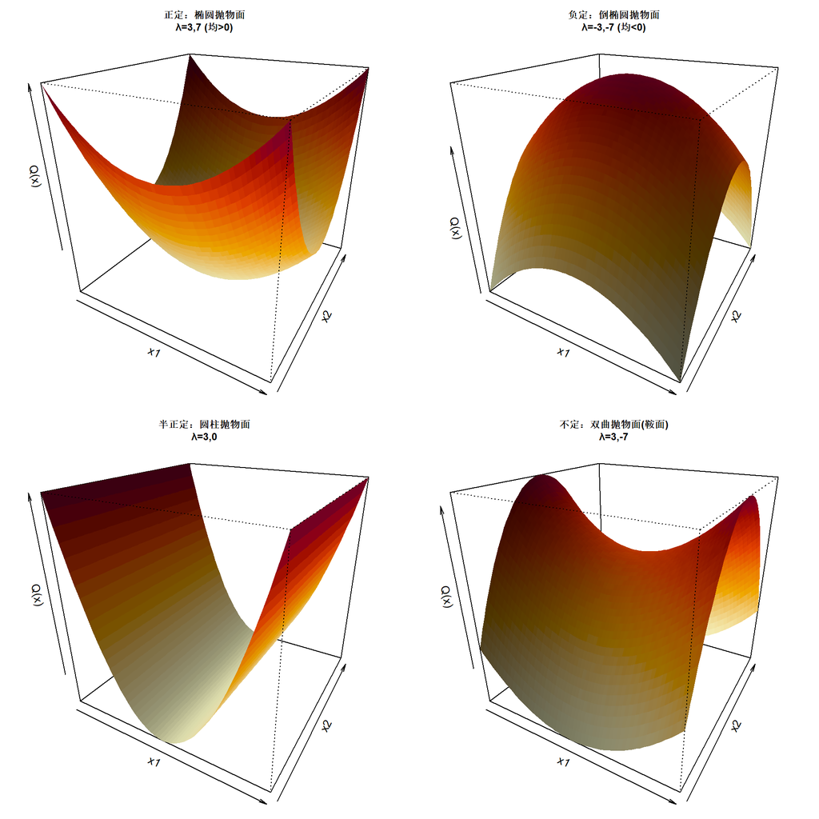

```r
# 定义四种典型二次型
cases <- list(
  list(A = matrix(c(3, 0, 0, 7), 2), title = "正定：椭圆抛物面\nλ=3,7 (均>0)"),
  list(A = matrix(c(-3, 0, 0, -7), 2), title = "负定：倒椭圆抛物面\nλ=-3,-7 (均<0)"),
  list(A = matrix(c(3, 0, 0, 0), 2), title = "半正定：圆柱抛物面\nλ=3,0"),
  list(A = matrix(c(3, 0, 0, -7), 2), title = "不定：双曲抛物面(鞍面)\nλ=3,-7")
)

x_seq <- seq(-2, 2, length.out = 60)
y_seq <- seq(-2, 2, length.out = 60)

par(mfrow = c(2, 2), mar = c(1, 1, 3, 1))
for (cs in cases) {
  A <- cs$A
  z <- outer(x_seq, y_seq, function(x, y) {
    A[1,1]*x^2 + (A[1,2]+A[2,1])*x*y + A[2,2]*y^2
  })

  col_palette <- hcl.colors(50, "YlOrRd", rev = TRUE)
  z_facet <- z[-1, -1] + z[-1, -ncol(z)] + z[-nrow(z), -1] + z[-nrow(z), -ncol(z)]
  facet_col <- col_palette[cut(z_facet, 50, labels = FALSE)]

  persp(x_seq, y_seq, z, theta = 30, phi = 25, col = facet_col,
        border = NA, shade = 0.4,
        xlab = "x1", ylab = "x2", zlab = "Q(x)",
        main = cs$title, cex.main = 0.9)
}
```

**观察**：正定矩阵产生碗形（有全局最小值）；负定产生倒碗（全局最大值）；不定产生鞍面（既无最小也无最大）。特征值的符号决定了曲面沿各主轴的弯曲方向。

## 5.3 实验 4.3 —— 正定性判定

判定二次型正定性的关键准则：所有特征值为正 $\Rightarrow$ 正定。

```r
test_matrices <- list(
  "矩阵1" = matrix(c(4, 1, 1, 3), 2, byrow = TRUE),
  "矩阵2" = matrix(c(-2, 0, 0, -5), 2, byrow = TRUE),
  "矩阵3" = matrix(c(1, 2, 2, 1), 2, byrow = TRUE),
  "矩阵4" = matrix(c(3, 0, 0, 0), 2, byrow = TRUE)
)

for (nm in names(test_matrices)) {
  A <- test_matrices[[nm]]
  eigs <- eigen(A)$values

  if (all(eigs > 0)) {
    type <- "正定"
  } else if (all(eigs >= 0)) {
    type <- "半正定"
  } else if (all(eigs < 0)) {
    type <- "负定"
  } else if (all(eigs <= 0)) {
    type <- "半负定"
  } else {
    type <- "不定"
  }

  cat(sprintf("%s: 特征值 = (%.2f, %.2f) → %s\n", nm, eigs[1], eigs[2], type))
}
```

```
矩阵1: 特征值 = (4.62, 2.38) → 正定
矩阵2: 特征值 = (-2.00, -5.00) → 负定
矩阵3: 特征值 = (3.00, -1.00) → 不定
矩阵4: 特征值 = (3.00, 0.00) → 半正定
```

## 5.4 实验 4.4 —— 主轴定理：消除交叉项

通过正交变换 $y = P^T x$，二次型中的交叉项消失：$x^T A x = y^T \Lambda y = \sum \lambda_i y_i^2$。

```r
# 笔记中的例子
A <- matrix(c(5, 2,
              2, 2), nrow = 2, byrow = TRUE)

eig <- eigen(A)
P <- eig$vectors
lambda <- eig$values

cat("A =\n"); print(A)
```

```
A =
```

```
     [,1] [,2]
[1,]    5    2
[2,]    2    2
```

```r
cat("\n特征值：λ1 =", round(lambda[1], 4), ", λ2 =", round(lambda[2], 4), "\n")
```

```
特征值：λ1 = 6 , λ2 = 1
```

```r
cat("特征向量矩阵 P =\n"); print(round(P, 4))
```

```
特征向量矩阵 P =
```

```
        [,1]    [,2]
[1,] -0.8944  0.4472
[2,] -0.4472 -0.8944
```

```r
# 验证：取 x = (1, 2)
x <- c(1, 2)
y <- t(P) %*% x   # 新坐标

Q_original <- as.numeric(t(x) %*% A %*% x)
Q_new <- as.numeric(lambda[1] * y[1]^2 + lambda[2] * y[2]^2)

cat("\nx = (", x[1], ",", x[2], ")\n")
```

```
x = ( 1 , 2 )
```

```r
cat("y = P^T x = (", round(y[1], 4), ",", round(y[2], 4), ")\n")
```

```
y = P^T x = ( -1.7889 , -1.3416 )
```

```r
cat("原始二次型：5x1² + 4x1x2 + 2x2² =", Q_original, "\n")
```

```
原始二次型：5x1² + 4x1x2 + 2x2² = 21
```

```r
cat("变换后二次型：", round(lambda[1], 2), "y1² +", round(lambda[2], 2), "y2² =",
    round(Q_new, 4), "\n")
```

```
变换后二次型： 6 y1² + 1 y2² = 21
```

```r
cat("值相等：", all.equal(Q_original, Q_new), "\n")
```

```
值相等： TRUE
```

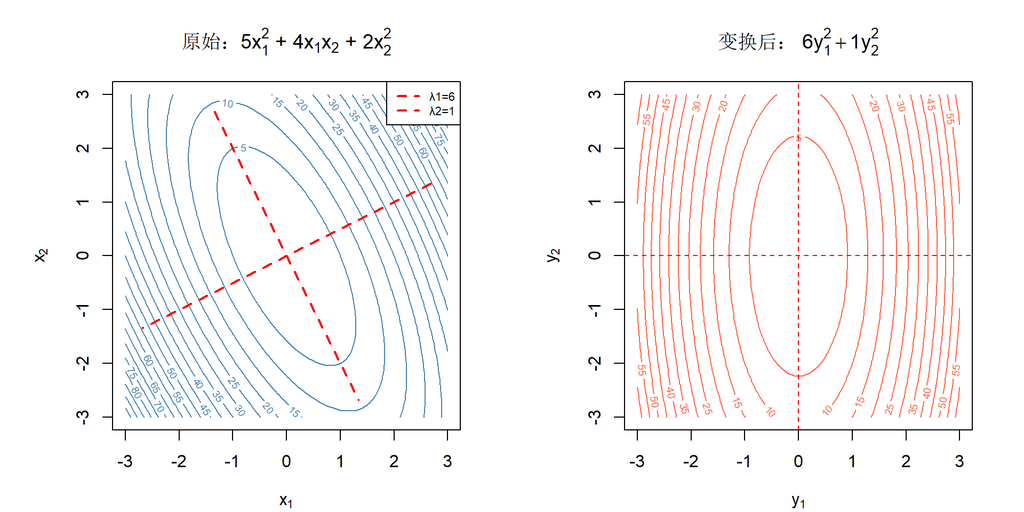

```r
# 可视化等高线
par(mfrow = c(1, 2), pty = "s", mar = c(4, 4, 4, 1))

x1_seq <- seq(-3, 3, length.out = 100)
x2_seq <- seq(-3, 3, length.out = 100)

# 原始坐标下的等高线（有交叉项，椭圆倾斜）
z_orig <- outer(x1_seq, x2_seq, function(x1, x2) 5*x1^2 + 4*x1*x2 + 2*x2^2)
contour(x1_seq, x2_seq, z_orig, nlevels = 15, col = "steelblue",
        main = expression("原始：5x"[1]^2*" + 4x"[1]*"x"[2]*" + 2x"[2]^2),
        xlab = expression(x[1]), ylab = expression(x[2]), asp = 1)
# 画特征方向
for (i in 1:2) {
  v <- P[, i]
  segments(-3*v[1], -3*v[2], 3*v[1], 3*v[2], col = "red", lwd = 2, lty = 2)
}
legend("topright", paste0("λ", 1:2, "=", round(lambda, 1)),
       col = "red", lty = 2, lwd = 2, cex = 0.7)

# 新坐标下的等高线（无交叉项，椭圆对齐坐标轴）
z_new <- outer(x1_seq, x2_seq, function(y1, y2) lambda[1]*y1^2 + lambda[2]*y2^2)
contour(x1_seq, x2_seq, z_new, nlevels = 15, col = "tomato",
        main = bquote("变换后："~.(round(lambda[1],1))*y[1]^2 + .(round(lambda[2],1))*y[2]^2),
        xlab = expression(y[1]), ylab = expression(y[2]), asp = 1)
abline(h = 0, v = 0, col = "red", lwd = 1, lty = 2)
```

**核心理解**：正交变换 $y = P^T x$ 将坐标轴旋转到特征向量方向。在新坐标下，椭圆的轴与坐标轴对齐，交叉项消失。函数值不变（$Q(x) = Q(y)$），变化的只是观察视角。

# 6 第五章：奇异值分解

## 6.1 实验 5.1 —— R 中的 SVD 计算

任意矩阵 $A = U \Sigma V^T$，$U$ 和 $V$ 正交，$\Sigma$ 对角。

```r
# 笔记中的例子
A <- matrix(c(1, 0, 1,
              0, 1, 1), nrow = 2, byrow = TRUE)

cat("A =\n"); print(A)
```

```
A =
```

```
     [,1] [,2] [,3]
[1,]    1    0    1
[2,]    0    1    1
```

```r
cat("A 的维度:", nrow(A), "×", ncol(A), "\n")
```

```
A 的维度: 2 × 3
```

```r
cat("A 的秩:", qr(A)$rank, "\n\n")
```

```
A 的秩: 2
```

```r
s <- svd(A)
cat("奇异值 σ:", round(s$d, 4), "\n\n")
```

```
奇异值 σ: 1.7321 1
```

```r
# R 的 svd() 返回简化形式：
#   U: m × min(m,n)    即 2×2
#   d: min(m,n) 个奇异值 即 长度 2
#   V: n × min(m,n)    即 3×2
cat("U (", nrow(s$u), "×", ncol(s$u), ") =\n"); print(round(s$u, 4))
```

```
U ( 2 × 2 ) =
```

```
        [,1]    [,2]
[1,] -0.7071 -0.7071
[2,] -0.7071  0.7071
```

```r
cat("\nV (", nrow(s$v), "×", ncol(s$v), ") =\n"); print(round(s$v, 4))
```

```
V ( 3 × 2 ) =
```

```
        [,1]    [,2]
[1,] -0.4082 -0.7071
[2,] -0.4082  0.7071
[3,] -0.8165  0.0000
```

```r
# 用简化形式重构：A = U diag(d) V^T
#   (2×2) %*% (2×2) %*% (2×3) = (2×3) ✓
A_recon <- s$u %*% diag(s$d) %*% t(s$v)
cat("\nU diag(σ) V^T =\n"); print(round(A_recon, 10))
```

```
U diag(σ) V^T =
```

```
     [,1] [,2] [,3]
[1,]    1    0    1
[2,]    0    1    1
```

```r
cat("重构误差:", max(abs(A - A_recon)), "\n")
```

```
重构误差: 4.440892e-16
```

```r
# 如果想看完整的 Σ 矩阵（m×n = 2×3）的样子：
Sigma_full <- matrix(0, nrow(A), ncol(A))
diag(Sigma_full) <- s$d
cat("\n完整 Σ (2×3) =\n"); print(round(Sigma_full, 4))
```

```
完整 Σ (2×3) =
```

```
       [,1] [,2] [,3]
[1,] 1.7321    0    0
[2,] 0.0000    1    0
```

```r
# 验证 U、V 的列正交
cat("\nU^T U =\n"); print(round(t(s$u) %*% s$u, 10))
```

```
U^T U =
```

```
     [,1] [,2]
[1,]    1    0
[2,]    0    1
```

```r
cat("V^T V =\n"); print(round(t(s$v) %*% s$v, 10))
```

```
V^T V =
```

```
     [,1] [,2]
[1,]    1    0
[2,]    0    1
```

## 6.2 实验 5.2 —— 单位圆到椭圆：SVD 的几何

矩阵 $A$ 将单位球变为椭球。奇异值是椭球半轴的长度，右奇异向量指向原空间中被拉伸最大/最小的方向，左奇异向量指向变换后椭球的主轴方向。

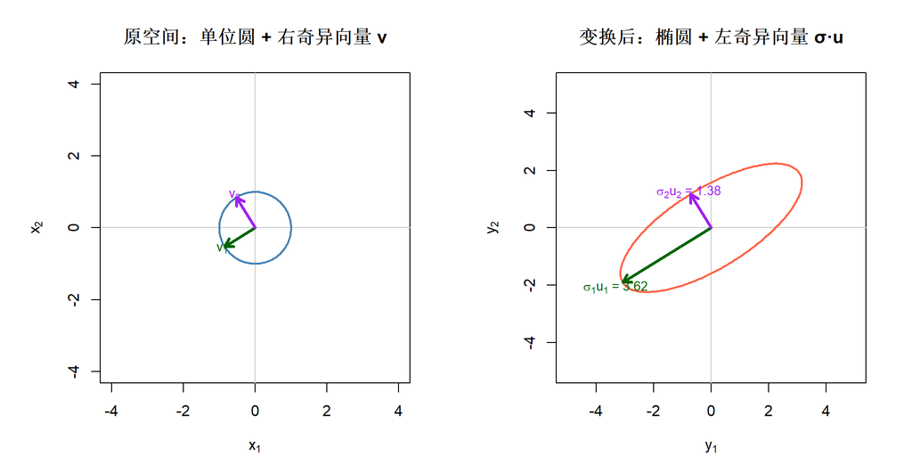

```r
A <- matrix(c(3, 1,
              1, 2), nrow = 2, byrow = TRUE)
s <- svd(A)

circ <- unit_circle()
ellip <- A %*% circ

par(mfrow = c(1, 2), pty = "s", mar = c(4, 4, 4, 1))

# 原空间：单位圆 + 右奇异向量
plot(NULL, xlim = c(-4, 4), ylim = c(-4, 4), asp = 1,
     main = "原空间：单位圆 + 右奇异向量 v",
     xlab = expression(x[1]), ylab = expression(x[2]))
abline(h = 0, v = 0, col = "gray80")
lines(circ[1, ], circ[2, ], col = "steelblue", lwd = 2)
draw_vector(s$v[, 1], col = "darkgreen", lwd = 3, label = expression(v[1]))
draw_vector(s$v[, 2], col = "purple", lwd = 3, label = expression(v[2]))

# 变换后：椭圆 + 左奇异向量（乘以奇异值）
plot(NULL, xlim = c(-5, 5), ylim = c(-5, 5), asp = 1,
     main = "变换后：椭圆 + 左奇异向量 σ·u",
     xlab = expression(y[1]), ylab = expression(y[2]))
abline(h = 0, v = 0, col = "gray80")
lines(ellip[1, ], ellip[2, ], col = "tomato", lwd = 2)
draw_vector(s$d[1] * s$u[, 1], col = "darkgreen", lwd = 3,
            label = bquote(sigma[1]*u[1]~"="~.(round(s$d[1], 2))))
draw_vector(s$d[2] * s$u[, 2], col = "purple", lwd = 3,
            label = bquote(sigma[2]*u[2]~"="~.(round(s$d[2], 2))))
```

```r
cat("奇异值：σ1 =", round(s$d[1], 4), ", σ2 =", round(s$d[2], 4), "\n")
```

```
奇异值：σ1 = 3.618 , σ2 = 1.382
```

```r
cat("σ1 是椭圆长轴长度，σ2 是短轴长度\n")
```

```
σ1 是椭圆长轴长度，σ2 是短轴长度
```

```r
cat("σ_max = max||Ax|| (||x||=1) =", round(s$d[1], 4), "\n")
```

```
σ_max = max||Ax|| (||x||=1) = 3.618
```

**观察**：右奇异向量 $v_1$ 指向被 $A$ 拉伸最多的输入方向，变换后它变成了长轴 $\sigma_1 u_1$。

## 6.3 实验 5.3 —— $A^T A$ 与奇异值的关系

$\|Ax\|^2 = x^T(A^T A)x$ 是关于对称矩阵 $A^T A$ 的二次型。$A^T A$ 的特征值就是 $A$ 的奇异值的平方。

```r
A <- matrix(c(1, 0, 1,
              0, 1, 1), nrow = 2, byrow = TRUE)

# 计算 A^T A
B <- t(A) %*% A
cat("A^T A =\n"); print(B)
```

```
A^T A =
```

```
     [,1] [,2] [,3]
[1,]    1    0    1
[2,]    0    1    1
[3,]    1    1    2
```

```r
cat("A^T A 是", nrow(B), "×", ncol(B), "的对称方阵\n")
```

```
A^T A 是 3 × 3 的对称方阵
```

```r
cat("对称性验证：", all(B == t(B)), "\n\n")
```

```
对称性验证： TRUE
```

```r
# A^T A 的特征值
eig_B <- eigen(B)
cat("A^T A 的特征值：", round(eig_B$values, 4), "\n")
```

```
A^T A 的特征值： 3 1 0
```

```r
cat("奇异值 = sqrt(特征值)：", round(sqrt(pmax(eig_B$values, 0)), 4), "\n")
```

```
奇异值 = sqrt(特征值)： 1.7321 1 0
```

```r
# 对比 SVD
s <- svd(A)
cat("SVD 得到的奇异值：", round(s$d, 4), "\n\n")
```

```
SVD 得到的奇异值： 1.7321 1
```

```r
# 验证右奇异向量 = A^T A 的特征向量
cat("A^T A 的特征向量（可能差一个符号）：\n")
```

```
A^T A 的特征向量（可能差一个符号）：
```

```r
print(round(eig_B$vectors, 4))
```

```
        [,1]    [,2]    [,3]
[1,] -0.4082  0.7071 -0.5774
[2,] -0.4082 -0.7071 -0.5774
[3,] -0.8165  0.0000  0.5774
```

```r
cat("\nSVD 的 V 矩阵：\n")
```

```
SVD 的 V 矩阵：
```

```r
print(round(s$v, 4))
```

```
        [,1]    [,2]
[1,] -0.4082 -0.7071
[2,] -0.4082  0.7071
[3,] -0.8165  0.0000
```

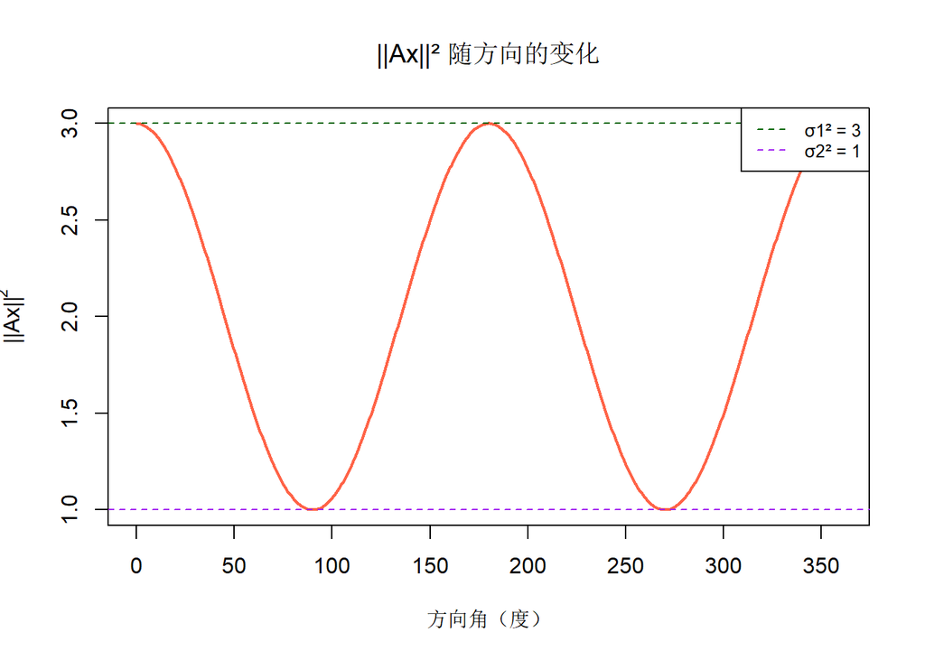

```r
# 可视化 ||Ax||^2 随方向变化
theta <- seq(0, 2 * pi, length.out = 500)
# 在 R^3 单位球面上取大圆上的点（用前两个坐标参数化）
# 简化：在 v1-v2 平面内取单位向量
V <- s$v
norms_sq <- numeric(length(theta))
for (k in seq_along(theta)) {
  # 在 v1-v2 张成的平面上取方向
  x_dir <- cos(theta[k]) * V[, 1] + sin(theta[k]) * V[, 2]
  x_dir <- x_dir / vnorm(x_dir)
  norms_sq[k] <- vnorm(A %*% x_dir)^2
}

plot(theta * 180 / pi, norms_sq, type = "l", lwd = 2, col = "tomato",
     xlab = "方向角（度）", ylab = expression("||Ax||"^2),
     main = expression("||Ax||² 随方向的变化"))
abline(h = s$d[1]^2, col = "darkgreen", lty = 2)
abline(h = s$d[2]^2, col = "purple", lty = 2)
legend("topright", c(paste0("σ1² = ", round(s$d[1]^2, 2)),
                     paste0("σ2² = ", round(s$d[2]^2, 2))),
       col = c("darkgreen", "purple"), lty = 2, cex = 0.8)
```

## 6.4 实验 5.4 —— SVD 分解三步走：旋转-拉伸-旋转

SVD 的几何含义是：$A = U \Sigma V^T$ 表示先旋转（$V^T$），再拉伸（$\Sigma$），最后再旋转（$U$）。

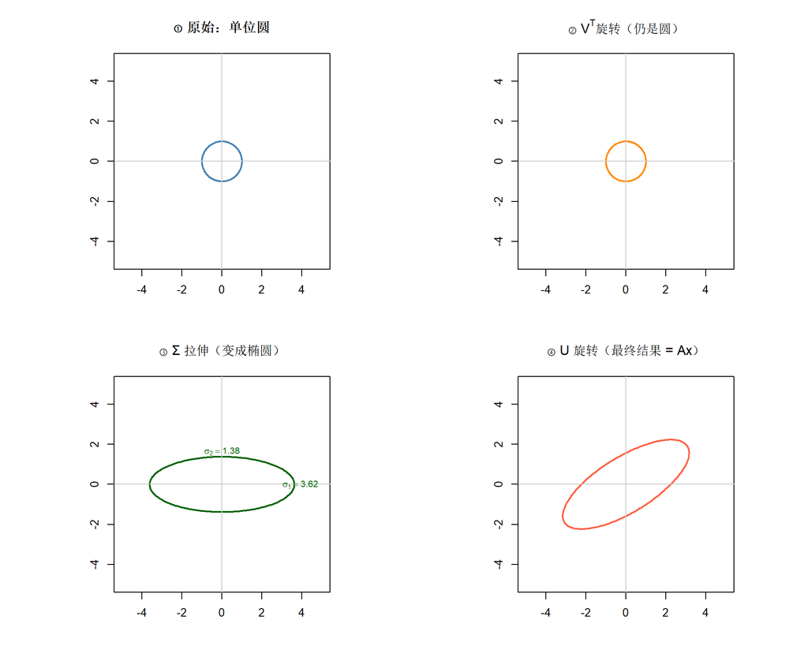

```r
A <- matrix(c(3, 1,
              1, 2), nrow = 2, byrow = TRUE)
s <- svd(A)

circ <- unit_circle()

# 三步变换
step1 <- t(s$v) %*% circ     # V^T: 旋转
step2 <- diag(s$d) %*% step1  # Σ: 拉伸
step3 <- s$u %*% step2        # U: 旋转

par(mfrow = c(2, 2), pty = "s", mar = c(4, 4, 4, 1))
lim <- 5

# 原始
plot(circ[1,], circ[2,], type = "l", col = "steelblue", lwd = 2, asp = 1,
     xlim = c(-lim, lim), ylim = c(-lim, lim),
     main = "① 原始：单位圆", xlab = "", ylab = "")
abline(h = 0, v = 0, col = "gray80")

# V^T 旋转
plot(step1[1,], step1[2,], type = "l", col = "darkorange", lwd = 2, asp = 1,
     xlim = c(-lim, lim), ylim = c(-lim, lim),
     main = expression("② V"^T*"旋转（仍是圆）"), xlab = "", ylab = "")
abline(h = 0, v = 0, col = "gray80")

# Σ 拉伸
plot(step2[1,], step2[2,], type = "l", col = "darkgreen", lwd = 2, asp = 1,
     xlim = c(-lim, lim), ylim = c(-lim, lim),
     main = expression("③ Σ 拉伸（变成椭圆）"), xlab = "", ylab = "")
abline(h = 0, v = 0, col = "gray80")
# 标注轴长
text(s$d[1] + 0.3, 0, bquote(sigma[1]==.(round(s$d[1], 2))), col = "darkgreen", cex = 0.8)
text(0, s$d[2] + 0.3, bquote(sigma[2]==.(round(s$d[2], 2))), col = "darkgreen", cex = 0.8)

# U 旋转
plot(step3[1,], step3[2,], type = "l", col = "tomato", lwd = 2, asp = 1,
     xlim = c(-lim, lim), ylim = c(-lim, lim),
     main = expression("④ U 旋转（最终结果 = Ax）"), xlab = "", ylab = "")
abline(h = 0, v = 0, col = "gray80")
```

**理解**：任何线性变换都可以分解为”旋转→拉伸→旋转”三步。$V^T$ 先把输入对齐到特征方向上，$\Sigma$ 沿各方向独立拉伸，$U$ 把结果旋转到输出空间的正确方向。

## 6.5 实验 5.5 —— 降维矩阵与维度变换

非方阵实现维度间的映射：$\mathbb{R}^n \to \mathbb{R}^m$。

```r
# 维度消除矩阵：R^3 -> R^2
D_reduce <- matrix(c(1, 0, 0,
                     0, 1, 0), nrow = 2, byrow = TRUE)
x3 <- c(1, 2, 7)
cat("维度消除：\n")
```

```
维度消除：
```

```r
cat("D =\n"); print(D_reduce)
```

```
D =
```

```
     [,1] [,2] [,3]
[1,]    1    0    0
[2,]    0    1    0
```

```r
cat("x =", x3, "\n")
```

```
x = 1 2 7
```

```r
cat("Dx =", D_reduce %*% x3, " (丢弃第三维)\n\n")
```

```
Dx = 1 2  (丢弃第三维)
```

```r
# 维度增加矩阵：R^2 -> R^3
D_expand <- matrix(c(1, 0,
                     0, 1,
                     0, 0), nrow = 3, byrow = TRUE)
x2 <- c(3, 5)
cat("维度增加：\n")
```

```
维度增加：
```

```r
cat("D =\n"); print(D_expand)
```

```
D =
```

```
     [,1] [,2]
[1,]    1    0
[2,]    0    1
[3,]    0    0
```

```r
cat("x =", x2, "\n")
```

```
x = 3 5
```

```r
cat("Dx =", D_expand %*% x2, " (第三维补零)\n\n")
```

```
Dx = 3 5 0  (第三维补零)
```

```r
# SVD 中非方阵的意义
A <- matrix(c(1, 0, 1,
              0, 1, 1), nrow = 2, byrow = TRUE)  # 2×3：R^3 -> R^2
s <- svd(A)
cat("2×3 矩阵的 SVD 维度：\n")
```

```
2×3 矩阵的 SVD 维度：
```

```r
cat("  U:", nrow(s$u), "×", ncol(s$u), "\n")
```

```
  U: 2 × 2
```

```r
cat("  Σ 对角元:", round(s$d, 4), " (在", nrow(A), "×", ncol(A), "矩阵中)\n")
```

```
  Σ 对角元: 1.7321 1  (在 2 × 3 矩阵中)
```

```r
cat("  V:", nrow(s$v), "×", ncol(s$v), "\n")
```

```
  V: 3 × 2
```

```r
cat("  秩 r =", sum(s$d > 1e-10), "\n")
```

```
  秩 r = 2
```

# 7 第六章：迹与范数

## 7.1 实验 6.1 —— 迹的计算与性质

迹 $\text{tr}(A) = \sum_{i} a_{ii}$ 是对角元素之和。迹有许多优美的性质，尤其是循环交换性 $\text{tr}(AB) = \text{tr}(BA)$。

```r
A <- matrix(c(1, 2, 3, 4, 5, 6, 7, 8, 9), 3, byrow = TRUE)
B <- matrix(c(9, 8, 7, 6, 5, 4, 3, 2, 1), 3, byrow = TRUE)

# 定义迹函数
tr <- function(M) sum(diag(M))

cat("A =\n"); print(A)
```

```
A =
```

```
     [,1] [,2] [,3]
[1,]    1    2    3
[2,]    4    5    6
[3,]    7    8    9
```

```r
cat("B =\n"); print(B)
```

```
B =
```

```
     [,1] [,2] [,3]
[1,]    9    8    7
[2,]    6    5    4
[3,]    3    2    1
```

```r
# 性质 1：tr(A) = tr(A^T)
cat("\ntr(A) =", tr(A), "\n")
```

```
tr(A) = 15
```

```r
cat("tr(A^T) =", tr(t(A)), "\n")
```

```
tr(A^T) = 15
```

```r
# 性质 2：线性性
c1 <- 2; c2 <- 3
cat("\ntr(", c1, "A +", c2, "B) =", tr(c1 * A + c2 * B), "\n")
```

```
tr( 2 A + 3 B) = 75
```

```r
cat(c1, "tr(A) +", c2, "tr(B) =", c1 * tr(A) + c2 * tr(B), "\n")
```

```
2 tr(A) + 3 tr(B) = 75
```

```r
# 性质 3：tr(AB) = tr(BA)
cat("\ntr(AB) =", tr(A %*% B), "\n")
```

```
tr(AB) = 189
```

```r
cat("tr(BA) =", tr(B %*% A), "\n")
```

```
tr(BA) = 189
```

```r
# 迹与特征值的关系
eig_A <- eigen(A)$values
cat("\nA 的特征值之和 =", round(sum(eig_A), 4), "\n")
```

```
A 的特征值之和 = 15
```

```r
cat("tr(A) =", tr(A), "\n")
```

```
tr(A) = 15
```

```r
cat("（迹等于特征值之和）\n")
```

```
（迹等于特征值之和）
```

## 7.2 实验 6.2 —— 常见矩阵范数

不同范数衡量矩阵”大小”的不同方面：总能量（Frobenius）、最大拉伸（谱范数）、列/行极端程度。

```r
A <- matrix(c(1, -2, 3,
              4,  5, -6), nrow = 2, byrow = TRUE)
cat("A =\n"); print(A)
```

```
A =
```

```
     [,1] [,2] [,3]
[1,]    1   -2    3
[2,]    4    5   -6
```

```r
# Frobenius 范数：所有元素平方和的平方根
frob <- sqrt(sum(A^2))
frob_trace <- sqrt(tr(t(A) %*% A))  # 也等于 sqrt(tr(A^T A))
cat("\nFrobenius 范数：||A||_F =", round(frob, 4), "\n")
```

```
Frobenius 范数：||A||_F = 9.5394
```

```r
cat("sqrt(tr(A^T A)) =", round(frob_trace, 4), "\n")
```

```
sqrt(tr(A^T A)) = 9.5394
```

```r
# 谱范数：最大奇异值
sigma_max <- max(svd(A)$d)
cat("\n谱范数：||A||_2 = σ_max =", round(sigma_max, 4), "\n")
```

```
谱范数：||A||_2 = σ_max = 9.225
```

```r
# 列和范数：每列绝对值之和的最大值
col_sums <- apply(abs(A), 2, sum)
cat("\n列和范数：||A||_1 =", max(col_sums), "\n")
```

```
列和范数：||A||_1 = 9
```

```r
cat("  各列绝对值之和：", col_sums, "\n")
```

```
  各列绝对值之和： 5 7 9
```

```r
# 行和范数：每行绝对值之和的最大值
row_sums <- apply(abs(A), 1, sum)
cat("\n行和范数：||A||_∞ =", max(row_sums), "\n")
```

```
行和范数：||A||_∞ = 15
```

```r
cat("  各行绝对值之和：", row_sums, "\n")
```

```
  各行绝对值之和： 6 15
```

```r
# 验证谱范数与 A^T A 的关系
ATA <- t(A) %*% A
lambda_max <- max(eigen(ATA)$values)
cat("\n验证：sqrt(λ_max(A^T A)) =", round(sqrt(lambda_max), 4), "\n")
```

```
验证：sqrt(λ_max(A^T A)) = 9.225
```

## 7.3 实验 6.3 —— 算子范数与瑞丽商

算子范数 $\|A\| = \max_{\|x\|=1} \|Ax\|$ 衡量矩阵最大能把向量”放大”多少倍。瑞丽商 $R_A(x) = \|Ax\|/\|x\|$ 是这个放大倍数的方向依赖版本。

```r
A <- matrix(c(3, 1,
              2, 2), nrow = 2, byrow = TRUE)

# 对所有单位向量方向计算瑞丽商
theta <- seq(0, 2 * pi, length.out = 1000)
rayleigh <- numeric(length(theta))
for (k in seq_along(theta)) {
  x <- c(cos(theta[k]), sin(theta[k]))
  rayleigh[k] <- vnorm(A %*% x)  # ||x|| = 1，所以瑞丽商就是 ||Ax||
}

# 算子范数 = 瑞丽商的最大值
op_norm <- max(rayleigh)
max_idx <- which.max(rayleigh)
max_dir <- c(cos(theta[max_idx]), sin(theta[max_idx]))

cat("算子范数 ||A||_2 =", round(op_norm, 4), "\n")
```

```
算子范数 ||A||_2 = 4.1306
```

```r
cat("最大拉伸方向：(", round(max_dir, 4), ")\n")
```

```
最大拉伸方向：( -0.8652 -0.5014 )
```

```r
cat("最大奇异值 σ_max =", round(max(svd(A)$d), 4), "\n")
```

```
最大奇异值 σ_max = 4.1306
```

```r
# 笔记中的例子
x_example <- c(1, 0)
Ax_example <- A %*% x_example
R_example <- vnorm(as.numeric(Ax_example)) / vnorm(x_example)
cat("\n例：x = (1,0)^T, Ax = (", Ax_example, ")\n")
```

```
例：x = (1,0)^T, Ax = ( 3 2 )
```

```r
cat("R_A(x) = ||Ax||/||x|| =", round(R_example, 4), "\n")
```

```
R_A(x) = ||Ax||/||x|| = 3.6056
```

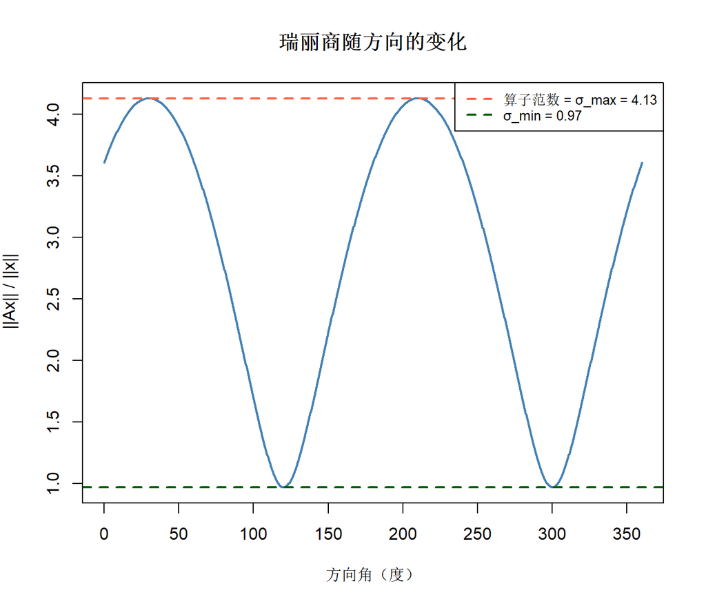

```r
# 可视化
plot(theta * 180 / pi, rayleigh, type = "l", lwd = 2, col = "steelblue",
     xlab = "方向角（度）", ylab = expression("||Ax|| / ||x||"),
     main = "瑞丽商随方向的变化")
abline(h = op_norm, col = "tomato", lwd = 2, lty = 2)
abline(h = min(rayleigh), col = "darkgreen", lwd = 2, lty = 2)
legend("topright",
       c(paste0("算子范数 = σ_max = ", round(op_norm, 2)),
         paste0("σ_min = ", round(min(rayleigh), 2))),
       col = c("tomato", "darkgreen"), lty = 2, lwd = 2, cex = 0.8)
```

**观察**：瑞丽商的最大值恰好等于最大奇异值，最小值等于最小奇异值。算子范数告诉我们矩阵 $A$ 在”最危险方向”上的放大能力。

# 8 第七章：综合实验

## 8.1 实验 7.1 —— 从特征分解到 SVD 的桥梁

将前面学到的所有概念串联起来：对称矩阵的特征分解就是它的 SVD。

```r
# 对称矩阵
A_sym <- matrix(c(5, 2,
                  2, 2), nrow = 2, byrow = TRUE)

# 特征分解
eig <- eigen(A_sym)

# SVD
s <- svd(A_sym)

cat("=== 对称矩阵 ===\n")
```

```
=== 对称矩阵 ===
```

```r
cat("A =\n"); print(A_sym)
```

```
A =
```

```
     [,1] [,2]
[1,]    5    2
[2,]    2    2
```

```r
cat("\n--- 特征分解 ---\n")
```

```
--- 特征分解 ---
```

```r
cat("特征值：", round(eig$values, 4), "\n")
```

```
特征值： 6 1
```

```r
cat("特征向量 P：\n"); print(round(eig$vectors, 4))
```

```
特征向量 P：
```

```
        [,1]    [,2]
[1,] -0.8944  0.4472
[2,] -0.4472 -0.8944
```

```r
cat("\n--- SVD ---\n")
```

```
--- SVD ---
```

```r
cat("奇异值：", round(s$d, 4), "\n")
```

```
奇异值： 6 1
```

```r
cat("U：\n"); print(round(s$u, 4))
```

```
U：
```

```
        [,1]    [,2]
[1,] -0.8944 -0.4472
[2,] -0.4472  0.8944
```

```r
cat("V：\n"); print(round(s$v, 4))
```

```
V：
```

```
        [,1]    [,2]
[1,] -0.8944 -0.4472
[2,] -0.4472  0.8944
```

```r
cat("\n对称矩阵的特征值 = 奇异值（取绝对值后排序）\n")
```

```
对称矩阵的特征值 = 奇异值（取绝对值后排序）
```

```r
cat("对称矩阵的 U ≈ V ≈ P（可能差一个符号）\n")
```

```
对称矩阵的 U ≈ V ≈ P（可能差一个符号）
```

```r
# 非对称矩阵则不同
cat("\n=== 非对称矩阵 ===\n")
```

```
=== 非对称矩阵 ===
```

```r
A_nonsym <- matrix(c(1, 3, 0, 2), 2, byrow = TRUE)
eig2 <- eigen(A_nonsym)
s2 <- svd(A_nonsym)
cat("特征值：", round(eig2$values, 4), "\n")
```

```
特征值： 2 1
```

```r
cat("奇异值：", round(s2$d, 4), "\n")
```

```
奇异值： 3.7025 0.5402
```

```r
cat("非对称时，特征值 ≠ 奇异值\n")
```

```
非对称时，特征值 ≠ 奇异值
```

## 8.2 实验 7.2 —— 综合可视化：一个矩阵的全面画像

给定一个矩阵，综合展示它的变换效果、特征结构和 SVD 结构。

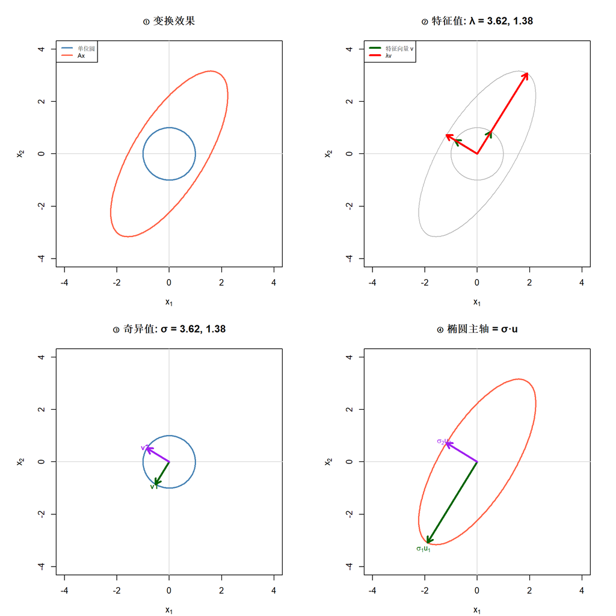

```r
A <- matrix(c(2, 1,
              1, 3), nrow = 2, byrow = TRUE)

eig <- eigen(A)
s <- svd(A)
circ <- unit_circle()
ellip <- A %*% circ

par(mfrow = c(2, 2), pty = "s", mar = c(4, 4, 4, 1))

# (1) 变换效果
plot(NULL, xlim = c(-4, 4), ylim = c(-4, 4), asp = 1,
     main = "① 变换效果", xlab = expression(x[1]), ylab = expression(x[2]))
abline(h = 0, v = 0, col = "gray85")
lines(circ[1,], circ[2,], col = "steelblue", lwd = 2)
lines(ellip[1,], ellip[2,], col = "tomato", lwd = 2)
legend("topleft", c("单位圆", "Ax"), col = c("steelblue", "tomato"), lwd = 2, cex = 0.7)

# (2) 特征向量
plot(NULL, xlim = c(-4, 4), ylim = c(-4, 4), asp = 1,
     main = paste0("② 特征值: λ = ", paste(round(eig$values, 2), collapse = ", ")),
     xlab = expression(x[1]), ylab = expression(x[2]))
abline(h = 0, v = 0, col = "gray85")
lines(circ[1,], circ[2,], col = "gray70", lwd = 1)
lines(ellip[1,], ellip[2,], col = "gray70", lwd = 1)
for (i in 1:2) {
  v <- eig$vectors[, i]
  draw_vector(v, col = "darkgreen", lwd = 3)
  draw_vector(eig$values[i] * v, col = "red", lwd = 3)
}
legend("topleft", c("特征向量 v", "λv"), col = c("darkgreen", "red"), lwd = 3, cex = 0.7)

# (3) SVD 右奇异向量
plot(NULL, xlim = c(-4, 4), ylim = c(-4, 4), asp = 1,
     main = paste0("③ 奇异值: σ = ", paste(round(s$d, 2), collapse = ", ")),
     xlab = expression(x[1]), ylab = expression(x[2]))
abline(h = 0, v = 0, col = "gray85")
lines(circ[1,], circ[2,], col = "steelblue", lwd = 2)
draw_vector(s$v[, 1], col = "darkgreen", lwd = 3, label = "v1")
draw_vector(s$v[, 2], col = "purple", lwd = 3, label = "v2")

# (4) SVD 左奇异向量（乘以奇异值）
plot(NULL, xlim = c(-4, 4), ylim = c(-4, 4), asp = 1,
     main = "④ 椭圆主轴 = σ·u",
     xlab = expression(x[1]), ylab = expression(x[2]))
abline(h = 0, v = 0, col = "gray85")
lines(ellip[1,], ellip[2,], col = "tomato", lwd = 2)
draw_vector(s$d[1] * s$u[, 1], col = "darkgreen", lwd = 3,
            label = bquote(sigma[1]*u[1]))
draw_vector(s$d[2] * s$u[, 2], col = "purple", lwd = 3,
            label = bquote(sigma[2]*u[2]))
```

## 8.3 实验 7.3 —— 常用性质速查与验证

用 R 快速验证线性代数中常用的恒等式和性质。

```r
A <- matrix(c(3, 1, 1, 4), 2, byrow = TRUE)  # 对称矩阵

cat("===== 常用性质验证 =====\n\n")
```

```
===== 常用性质验证 =====
```

```r
# 1. 对称矩阵
cat("1. A 是对称的：", all(A == t(A)), "\n")
```

```
1. A 是对称的： TRUE
```

```r
# 2. 正交矩阵的逆
U <- eigen(A)$vectors
cat("2. 特征向量矩阵 U 正交：max|U^TU - I| =",
    max(abs(t(U) %*% U - diag(2))), "\n")
```

```
2. 特征向量矩阵 U 正交：max|U^TU - I| = 2.220446e-16
```

```r
cat("   U^{-1} = U^T：", all.equal(solve(U), t(U)), "\n")
```

```
   U^{-1} = U^T： TRUE
```

```r
# 3. 对称矩阵特征值是实数
cat("3. 对称矩阵特征值都是实数：", all(Im(eigen(A)$values) == 0), "\n")
```

```
3. 对称矩阵特征值都是实数： TRUE
```

```r
# 4. 不同特征值的特征向量正交
v1 <- eigen(A)$vectors[, 1]
v2 <- eigen(A)$vectors[, 2]
cat("4. 不同特征值的特征向量正交：<v1,v2> =", round(sum(v1 * v2), 10), "\n")
```

```
4. 不同特征值的特征向量正交：<v1,v2> = 0
```

```r
# 5. det(A) = 特征值之积
cat("5. det(A) =", det(A), ", 特征值之积 =", round(prod(eigen(A)$values), 4), "\n")
```

```
5. det(A) = 11 , 特征值之积 = 11
```

```r
# 6. tr(A) = 特征值之和
cat("6. tr(A) =", sum(diag(A)), ", 特征值之和 =", round(sum(eigen(A)$values), 4), "\n")
```

```
6. tr(A) = 7 , 特征值之和 = 7
```

```r
# 7. ||A||_2 = σ_max = sqrt(λ_max(A^TA))
cat("7. 谱范数 = σ_max =", round(max(svd(A)$d), 4), "\n")
```

```
7. 谱范数 = σ_max = 4.618
```

```r
cat("   sqrt(λ_max(A^TA)) =", round(sqrt(max(eigen(t(A)%*%A)$values)), 4), "\n")
```

```
   sqrt(λ_max(A^TA)) = 4.618
```

```r
# 8. Frobenius 范数 = sqrt(Σ σ_i²)
cat("8. ||A||_F =", round(sqrt(sum(A^2)), 4), "\n")
```

```
8. ||A||_F = 5.1962
```

```r
cat("   sqrt(Σ σ²) =", round(sqrt(sum(svd(A)$d^2)), 4), "\n")
```

```
   sqrt(Σ σ²) = 5.1962
```

# 附录：R 线性代数速查表

```r
# ===== R 线性代数核心函数 =====

# 矩阵创建
A <- matrix(c(1,2,3,4), nrow = 2, byrow = TRUE)  # 按行填充
I <- diag(3)                                        # 3×3 单位矩阵
D <- diag(c(1, 2, 3))                              # 对角矩阵

# 基本运算
A %*% B          # 矩阵乘法
t(A)             # 转置
solve(A)         # 求逆
solve(A, b)      # 解方程 Ax = b
det(A)           # 行列式
sum(diag(A))     # 迹

# 特征分解
eig <- eigen(A)
eig$values       # 特征值
eig$vectors      # 特征向量（列向量）

# 奇异值分解
s <- svd(A)
s$d              # 奇异值
s$u              # 左奇异向量
s$v              # 右奇异向量

# QR 分解（与 Gram-Schmidt 相关）
qr_result <- qr(A)
Q <- qr.Q(qr_result)  # 正交矩阵
R <- qr.R(qr_result)  # 上三角矩阵

# 秩
qr(A)$rank

# 范数
sqrt(sum(x^2))          # 向量 2-范数
sqrt(sum(A^2))          # Frobenius 范数
max(svd(A)$d)           # 谱范数
max(colSums(abs(A)))    # 列和范数
max(rowSums(abs(A)))    # 行和范数
```

[output not shown]